# Economic impacts of climate change on agriculture: The importance of additional climatic variables other than temperature and precipitation - ScienceDirect

## [Journal of Environmental Economics and Management](https://www.sciencedirect.com/journal/journal-of-environmental-economics-and-management)

[Volume 83](https://www.sciencedirect.com/journal/journal-of-environmental-economics-and-management/vol/83/suppl/C), May 2017, Pages 8-31

# Economic impacts of climate change on agriculture: The importance of additional climatic variables other than temperature and precipitation

https://doi.org/10.1016/j.jeem.2016.12.001[Get rights and content](https://s100.copyright.com/AppDispatchServlet?publisherName=ELS&contentID=S0095069616304910&orderBeanReset=true)

Abstract

Climate change shifts the distributions of a set of climatic variables, including temperature, precipitation, humidity, wind speed, sunshine duration, and evaporation. This paper explores the importance of those additional climatic variables other than temperature and precipitation. Using the county-level agricultural data from 1980 to 2010 in China, we find that those additional climatic variables, especially humidity and wind speed, are critical for crop growth. Therefore, omitting those variables is likely to bias the predicted impacts of climate change on crop yields. In particular, omitting humidity tends to overpredict the cost of climate change on crop yields, while ignoring wind speed is likely to underpredict the effect. Our preferred specification indicates that climate change is likely to decrease the yields of rice, wheat, and corn in China by 36.25%, 18.26%, and 45.10%, respectively, by the end of this century.

## JEL classification

Q54

Q56

C23

## Keywords

Climate change

Agriculture

Humidity

Wind speed

China

## Introduction

Over the past decade, a growing body of economics research has projected the impacts of climate change on important facets of well-being, such as agriculture, industry, human health, energy demand, and economic growth (Dell et al., 2014). Given the natural relationship between climatic factors and plant growth, the agricultural sector is thoroughly researched (Mendelsohn et al., 1994, Schlenker et al., 2005, Schlenker et al., 2006, Deschênes and Greenstone, 2007, Schlenker and Roberts, 2009, Welch et al., 2010, Deschênes and Greenstone, 2012, Fisher et al., 2012, Roberts et al., 2012, Lobell et al., 2013, Chen et al., 2015, Burke and Emerick, 2016). However, the majority of these studies focus on temperature and precipitation, largely ignoring other climatic variables such as humidity, wind speed, sunshine duration, and evaporation (hereinafter referred to as additional climatic variables).<sup>1</sup> Though some studies have included one additional climatic variable, to our best knowledge, none have systematically studied this issue.<sup>2</sup> Therefore, this paper identifies the key climatic variables besides temperature and precipitation that should be included in the models that use reduced-form econometrics to evaluate the impacts of climate change.

Omitting additional climatic variables can bias the predicted cost of climate change for a number of reasons. First, climate change shifts the distributions of a set of climatic variables (Hartmann et al., 2013), which is illustrated in Fig. 1 according to the widely used Hadley Model. Second, additional climatic variables could be essential for crop growth (Hoffman and Jobes, 1978, Nobel, 1981, Gallagher and Biscoe, 1978, Batchelor and Roberts, 1983). Furthermore, omitting additional climatic variables may also bias the estimated coefficients of temperature and precipitation, because climatic variables are highly inter-correlated (see Table 1) (Lawrence, 2005, Wooten, 2011, Rebetez and Beniston, 1998, Nkemdirim, 1991). As a consequence, including temperature and precipitation only is insufficient. The net effect of all climatic variables is essentially an empirical question.

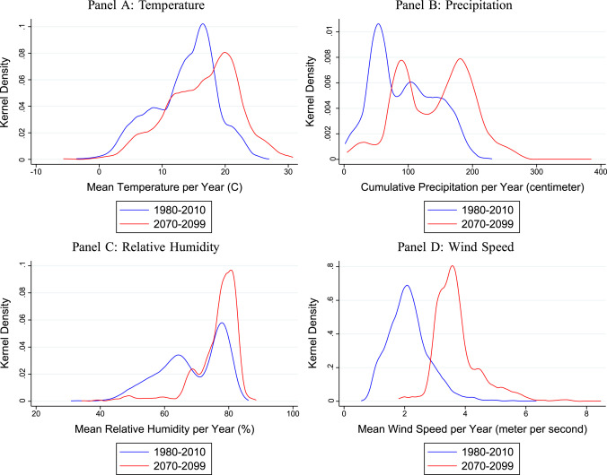

Fig. 1. The Kernel Density for Temperature, Precipitation, Relative Humidity and Wind Speed (1980–2010, 2070–2099). *Notes*: The observations are calculated at the county-year level. Temperature, relative humidity, and wind speed are annual averages calculated using daily values. Precipitation is calculated as the annual cumulative value. The blue line denotes historical distribution (1980–2010), while the red line represents forecast distribution (2070–2099). (For interpretation of the references to color in this figure caption, the reader is referred to the web version of this paper.)

Table 1. Correlation coefficients among climatic variables.

| Empty Cell | Tem | Pre | Hum | Win | Sun | Eva |
| --- | --- | --- | --- | --- | --- | --- |
| **Rice** |  |  |  |  |  |  |
| Temperature (°C) | 1.00 | — | — | — | — | — |
| Precipitation (cm) | 0.46 | 1.00 | — | — | — | — |
| Humidity (%) | 0.37 | 0.82 | 1.00 | — | — | — |
| Wind (m/s) | −0.52 | −0.55 | −0.42 | 1.00 | — | — |
| Sunshine (h) | −0.53 | −0.82 | −0.80 | 0.67 | 1.00 | — |
| Evaporation (mm) | −0.35 | −0.42 | −0.37 | 0.38 | 0.54 | 1.00 |
| **Wheat** |  |  |  |  |  |  |
| Temperature (°C) | 1.00 | — | — | — | — | — |
| Precipitation (cm) | 0.46 | 1.00 | — | — | — | — |
| Humidity (%) | 0.52 | 0.72 | 1.00 | — | — | — |
| Wind (m/s) | −0.41 | −0.34 | −0.30 | 1.00 | — | — |
| Sunshine (h) | −0.51 | −0.66 | −0.85 | 0.49 | 1.00 | — |
| Evaporation (mm) | −0.39 | −0.34 | −0.38 | 0.29 | 0.48 | 1.00 |
| **Corn** |  |  |  |  |  |  |
| Temperature (°C) | 1.00 | — | — | — | — | — |
| Precipitation (cm) | 0.21 | 1.00 | — | — | — | — |
| Humidity (%) | 0.32 | 0.59 | 1.00 | — | — | — |
| Wind (m/s) | −0.13 | 0.02 | −0.32 | 1.00 | — | — |
| Sunshine (h) | −0.20 | −0.37 | −0.79 | 0.56 | 1.00 | — |
| Evaporation (mm) | −0.28 | −0.17 | −0.42 | 0.36 | 0.58 | 1.00 |

*Notes*: Temperature, relative humidity, wind speed, sunshine duration, and evaporation are annual mean values, while precipitation is the annual cumulative value. All weather data are selected from the specific growing season of each crop.

In this paper, we explore the importance of those additional climatic variables—humidity, wind speed, sunshine duration, and evaporation—in the climate–agriculture relationship. Using the county-level agricultural data from 1980 to 2010 in China, we estimate and compare two models. The first model, referred to henceforth as the restricted model, includes only temperature and precipitation. The second model, referred to henceforth as the full model, includes additional climatic variables besides temperature and precipitation.

Our analysis shows that those additional climatic variables have both economically and statistically significant effects on crop yields. In particular, humidity is beneficial for all three crops. We find that a 1% increase in average humidity during the growing season boosts rice, wheat, and corn yields by 0.75%, 0.96%, and 0.61%, respectively. In addition, humidity during the two coldest months, January and February, plays a critical role in wheat growth; humidity during the two warmest months, July and August, is vital for corn.

We also find significant impacts of wind speed on crop growth, especially for rice and wheat. If average wind speed during the growing season increases by 1 meter per second, rice and wheat yields decrease by 14.51% and 13.91%, respectively. Furthermore, we find positive effects of sunshine duration on rice and corn yields. The point estimates suggest that if average sunshine duration during the growing season increases by 1 hour, rice and corn yields increase by 6.10% and 3.84%, respectively. As for evaporation, we do not find significant effects in general.

Including additional climatic variables also improves the model fits for rice and wheat. Compared with the model without any climatic variables, including temperature and precipitation decreases its [Bayesian information criterion](https://www.sciencedirect.com/topics/economics-econometrics-and-finance/bayesian-information-criterion) (BIC) by 7.95% for rice. When we further include additional climatic variables, the BIC is reduced to 14.68%. We find a similar effect on wheat. BIC is reduced by 39.82% for the restricted model and by 50.54% for the full model. However, the improvement in the model fit for corn is negligible.

The additional climatic variables make a significant difference in climate prediction. The restricted model predicts that climate change reduces rice yields by 31.90%. Controlling for average humidity during the growing season, the predicted cost reduces to 26.04%. Similarly, the predicted climatic effect changes from a loss of 11.85% to a gain of 3.14% for wheat, and from a loss of 47.10% to a loss of 42.59% for corn. These results indicate that increasing humidity will partially compensate the cost of rising temperatures. However, although annual average humidity is likely to increase (see Fig. 1), humidity during the warmest months tends to decline due to increases in extremely high temperatures.<sup>3</sup> Since the effect of humidity on corn is mostly pronounced from July to August, the predicted climate cost for corn increases from 42.59% to 48.78% when we control for humidity during the warmest months.

We find that omitting wind speed is likely to underestimate the cost of climate change. For instance, when we control for wind speed in addition to temperature, precipitation, and humidity, the predicted yield loss changes from 26.42% to 37.88% for rice, and from a gain of 0.29% to a loss of 15.26% for wheat. This is mainly because high wind speed is harmful for rice and wheat and the world is expected to be windier under climate change. The wind effect is small for corn. Controlling for sunshine duration and evaporation does not change the prediction results significantly for all three crops.

It is worth noting that our major findings are derived from the Chinese agriculture. Caution is needed to generalize the conclusion to other countries or crops. It is an empirical question of how omitted climatic variables can affect the estimates of the climate-agriculture relationship across different countries. The bottom line is that, those additional climatic variables should be carefully considered when estimating the impacts of climate change on agriculture, and possibly for other economic outcomes.

The rest of the paper is organized as follows. Section “Empirical background” presents the empirical background for our analysis. Section “Data sources and summary statistics” describes data sources and provides summary statistics. Section “Empirical strategy” presents our empirical strategy and Section “Empirical results” describes the results. Section “Climate change predictions” projects the impacts of climate change and Section “Conclusion” concludes.

## Empirical background

### Changes in the observable climatic variables

Climate change induced by anthropogenic [greenhouse gas emissions](https://www.sciencedirect.com/topics/economics-econometrics-and-finance/greenhouse-gas-emissions) has observable effects on the natural environment (Hartmann et al., 2013). The direct consequence of climate change is the rising global mean surface temperature. This heating effect will alter the hydrological cycle. A warmer planet will change the amount, intensity, frequency, and type of precipitation, and it will also increase the amount of water vapor in the atmosphere which will affect humidity. Furthermore, global warming has impacts on atmospheric circulation and can cause changes in wind speed. Therefore, the effects of climate change include a wide range of climatic variables, not just temperature and precipitation.

The Hadley Centre, a leading research institution on climate change in the world, has projected the changes of various climatic variables. To examine the effects of climate change in China, we compare the distributions of temperature, precipitation, relative humidity, and wind speed in two periods: 1980–2010 and 2070–2099.<sup>8</sup> The kernel densities of these climatic variables are illustrated in Fig. 1. The observation is at the county-year level. Temperature, relative humidity, and wind speed are calculated as annual averages, while precipitation is calculated as the annual cumulative amount. The blue lines denote the historical distribution (1980–2010), while the red lines represent the predicted distribution (2070–2099).

Fig. 1 clearly shows that climate change will alter the distributions of all four of these climatic variables in China. First, consistent with the literature, climate change shifts the distributions of both temperature and precipitation in a rightward direction. Thus, higher temperatures and increased levels of precipitation will be more frequent in the future. Second, climate change also alters the distributions of relative humidity and wind speed. Specifically, the bimodal distribution of relative humidity with two modes around 65% and 80% will almost become unimodal with the peak around 80%. Thus, climate change is likely to lead to a world with higher levels of humidity. It is noted that although annual average humidity tends to increase, humidity in the warmest months is likely to decrease due to increases in extremely high temperatures. Moreover, climate change also moves the distribution of wind speed to the right; wind speeds around 4 meters per second are more likely to occur. Therefore, a windier climate is expected in the future.

These climatic variables are generally inter-correlated (Lawrence, 2005, Wooten, 2011, Rebetez and Beniston, 1998, Nkemdirim, 1991). To illustrate this, Table 1 presents the correlation coefficients among these climatic variables. Temperature, relative humidity, wind speed, sunshine duration, and evaporation are calculated using annual mean values, while precipitation is calculated using annual cumulative value. All weather data are selected from the specific growing season of each crop. Table 1 shows strong and complex correlations among climatic variables. For example, temperature is positively correlated with precipitation and relative humidity, while negatively correlated with wind speed, sunshine duration, and evaporation. In addition, precipitation is positively correlated with humidity but negatively correlated with wind speed, sunshine duration, and evaporation.

### Relevance to crop yields

Temperature and precipitation are regarded as the two most important climate change indicators for agricultural production. Their impacts on agricultural land values (Mendelsohn et al., 1994, Schlenker et al., 2005, Schlenker et al., 2006, Deschênes and Greenstone, 2007) or crop yields (Deschênes and Greenstone, 2007, Schlenker and Roberts, 2009, Welch et al., 2010, Deschênes and Greenstone, 2012, Fisher et al., 2012, Roberts et al., 2012, Lobell et al., 2013, Chen et al., 2015, Burke and Emerick, 2016) have been extensively studied. However, other climatic factors—such as humidity, wind speed, sunshine duration, and evaporation—are also essential for crop growth. The agronomy literature has demonstrated the importance of those additional climatic variables alongside temperature and precipitation.

Humidity can affect crop growth in two ways. First, it can affect it directly by altering the water content of the plant. Secondly, it can affect indirectly by influencing leaf growth, photosynthesis, pollination, and likelihood of diseases (Hoffman and Jobes, 1978, Rawson et al., 1977, Sadras and Milroy, 1996). Cell enlargement is an important process for leaf growth, and this is typically a result of turgor pressure developed within the cells. Higher levels of humidity usually lead to less transpiration which in turn leads to high turgor pressure. Therefore, these higher levels promote leaf enlargement. Humidity can also affect photosynthesis by altering transpiration. When humidity levels are low, there will be more transpiration which will lead to water deficits in the plant. As a result, stomata will be partly or fully closed and the entry of carbon dioxide is blocked. Humidity could also affect pollination because the seed set in many crops prefers moderately low humidity. Additionally, anthers may not disperse pollen under particularly high levels of humidity. Lastly, when higher levels of humidity persist, insect pests and diseases, particularly those that originate from fungal spores on plant leaves, are more likely to occur.

Wind has a variety of physiological and mechanical effects on crops, such as changes in plant motion, uprooting of plants, physical leaf damage, sandblasting, and combined abrasion and tearing. In response to changes in wind patterns, crops might change their growth rate and morphology, resulting in different grain yields (Nobel, 1981, Grace, 1988). More specifically, high wind speeds can be detrimental to plants during events of extreme weather.

The sunshine duration that a crop receives is one of the most important factors that influences plants development (Gallagher and Biscoe, 1978, Monteith and Unsworth, 2013). It can alter leaf architecture and light partitioning. It activates the photosystem which in turn starts the light reaction of photosynthesis and the electrons generated by photolysis of water move to produce energy carriers (Richards, 2006, Ahmed and ul Hassan, 2011).

Evaporation, combined with temperature, is expected to increase plant evapotranspiration (Roderick and Farquhar, 2002). Evaporation also causes considerable water loss prior to the water transport to the fields where the crops are grown (Batchelor and Roberts, 1983, Wallace, 2000).

Overall, climate change will affect a set of climatic variables beyond temperature and precipitation. Specifically, as China is expecting a warmer, wetter, more humid, and windier climate on average by the end of this century, these changes will likely have many profound influences on the economic well-being, particularly on agriculture. Given that these variables have different impacts on crop growth, the direction and magnitude of the bias of omitting those variables is an empirical question.

### Chinese agriculture and climate change

Rice, wheat, and corn are the three major crops in China, as they compose 35%, 21%, and 34% of the total food grain production.<sup>13</sup> Fig. 2 depicts the yield distribution of rice, wheat, and corn in China. Rice is typically grown in southern China due to its warm and humid weather patterns. Around 16% of rice is also produced in the northeast.<sup>14</sup> In contrast, wheat is usually planted in northern and central China. Henan, Shandong, and Hebei are the major producers of wheat. Compared with rice and wheat, corn is more widely distributed across China, but the major provinces of corn production such as Heilongjiang, Hebei, Shandong, and Henan are located in northern and central China.

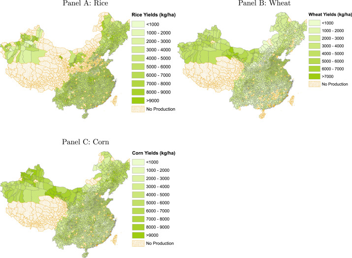

Fig. 2. Average Yields for Rice, Wheat and Corn in Kilogram per Hectare (1980–2010). *Notes*: Averages for each county are calculated over the period 1980–2010 in available years. The map includes the full sample. In the main article, we only focus on single-season rice, winter wheat, spring corn, summer corn, and autumn corn.

Climate change is a major concern for the Chinese agriculture, which is demonstrated in the most recent National Plan for Addressing Climate Change for 2014–2020.<sup>15</sup> The climatic impacts and adaptation strategies in agriculture are also highlighted in the Second National Communication on Climate Change that is submitted to the United Nations Framework Convention on Climate Change (UNFCCC).<sup>16</sup> In order to cope with climate change, the Chinese government has outlined the main adaptation strategies in agriculture in the ongoing 12th Five-year Plan. However, economic studies on the climatic impacts on agriculture are still very limited.<sup>17</sup> In order for China to make appropriate investments in climate mitigation and adaptation, it is vital to understand the true costs of climate change, in particularly for the agricultural sector.

## Data sources and summary statistics

### Data sources

*Agricultural production*: The county-level agriculture data come from the Chinese Academy of Agricultural Sciences, which collected this data jointly with the Ministry of Agriculture of China. They rely on the agricultural survey teams in Chinese county-level Bureaus of Agriculture. These teams have at least one surveyor in each village. These surveyors interview farmers to obtain agricultural production information. The data are then aggregated to the county level. There are no agricultural data in Xizang Autonomous Region (Tibet) and Qinghai Province for the three major crops. These two regions are located on the Qinghai-Tibet Plateau with average elevation over 4000 meters, so there are very few agricultural activities of the three major crops and thus the impact of this missing data on our analysis should be limited. The data exist from 1980 to the present. Due to budget constraints, we were only able to obtain the data in the years of 1980, 1985, 1990, 1995, 2000, 2004–2008, and 2010.

*Growing season*: Since China is a large country with heterogeneous geographic attributes, the growing season differs across regions, even for the same crop. We collated the growing season of each crop from various sources. The data on rice come from the China National Rice Research Institute and the China Rice Data Center. The data on wheat come from Zhao, 2010a, Zhao, 2010b and the data on corn come from Liu (1993).

In southern China, the rice cropping systems include double cropped rice (early and late rice), single-season rice, and mixed cropped rice. However, the data only have aggregate production and planted area for each year, and thus we are not able to differentiate early and late rice in double and mixed cropped regions. Therefore, following Chen et al. (2014), we focus on single-season rice only, which accounts for more than 50% of total rice production in China. The growing season for single-season rice in northern China typically lasts from April to October, while in the southwest it is generally from April to November.

There are two types of wheat in China: spring wheat and winter wheat. Spring wheat is generally grown north of the Great Wall from March to August, while winter wheat is typically grown south of the Great Wall from the previous September to June, or from the previous November to May in southern China. Since spring and winter wheat respond to weather differently, we drop spring wheat as it accounts for less than 10% of total wheat production in China.

China grows four types of corn: spring corn, summer corn, autumn corn, and winter corn. Generally, spring corn is grown in the north and northeast from April to September, summer corn from June to September in the north and central, autumn corn in the south from August to November, and winter corn in the tropical and subtropical regions from November to February. Because winter corn is mainly grown in winter and it only accounts for less than 5% of total corn production, we drop it from the baseline analysis. In the robustness checks, we include all types of rice, wheat, and corn, and the results remain the same.<sup>18</sup>

*Weather*: The weather data are from the National Meteorological Information Center of China, which is the official institute of weather data gathering and publishing. We obtained station-day level data for 821 stations across China from 1979 to 2010.<sup>19</sup> We drop stations with elevation greater than 3000 meters because stations may not provide any useful agricultural weather information if their elevation is too high (Deschênes and Greenstone, 2011).<sup>20</sup> To transform weather data from station level to county level, we use the inverse-distance weighting method, a standard method commonly used in the literature (Mendelsohn et al., 1994, Deschênes and Greenstone, 2007, Deschênes and Greenstone, 2011). First, we choose a circle with a 200 km radius for each county's centroid. We then take the weighted average of the weather data for all stations within the circle, where the weights are the inverse of the distance between each station and the county's centroid. Finally, we assign the weighted average to each county.<sup>21</sup>

*Climate prediction*: The data of climate change prediction are from the Hadley Centre in the United Kingdom, one of the world's leading institutes on climate change research. We use the Hadley Centre's third Coupled Ocean-Atmosphere [General Circulation Model](https://www.sciencedirect.com/topics/economics-econometrics-and-finance/general-circulation-models) (Hadley CM3), which has been commonly used in the literature (Schlenker et al., 2006, Schlenker and Roberts, 2009, Deschênes and Greenstone, 2011).<sup>22</sup> Hadley CM3 predicts daily temperature, precipitation, relative humidity, and wind speed for each grid points from 1990 to 2099. The grid points are separated by 2.5° latitude and 3.75° longitude globally. We focus on the “business-as-usual” scenario, or the so-called A1FI scenario. We choose the years from 2070 to 2099, a relatively long time frame, to predict the impacts of climate change. We again use the inverse-distance weighting method to transform the climate-change prediction data from the grid level to the county level.<sup>23</sup> Burke et al. (2015) suggest that there are large uncertainties between climate models. Therefore, we also report climate predictions using other climate models, including PCM, ECHAM, CGCM, and CCSM. Each model is associated with three forcing scenarios: B1, A1B, and A2. These models were used in the Intergovernmental Panel on Climate Change (IPCC) 5th Assessment Report.

### Summary statistics

Our agricultural data contain county-year level production (measured in kilograms, kg) and planted area (measured in hectares, ha) for rice, wheat, and corn.<sup>24</sup> The dependent variable, crop yields (measured in kg/ha), are defined as production divided by the planted area of the respective crop. This paper also uses daily historical weather data and climate change predictions to develop county-year measures of past and future climate. The climatic variables include temperature, precipitation, relative humidity, wind speed, sunshine duration, and evaporation.

Table 2. Summary statistics.

| Empty Cell | Past (1980–2010) Mean | Past (1980–2010) Min | Past (1980–2010) Max | Future (2070–2099) Mean | Future (2070–2099) Min | Future (2070–2099) Max |
| --- | --- | --- | --- | --- | --- | --- |
| **Rice** |  |  |  |  |  |  |
| Yields (kg/ha) | 6067 | 225 | 21,429 | — | — | — |
| Temperature (°C) | 19.65 | 8.33 | 28.20 | 22.18 | 4.40 | 27.65 |
| Precipitation (cm) | 72.20 | 0.30 | 193.54 | 111.18 | 3.91 | 234.63 |
| Relative humidity (%) | 70.66 | 30.14 | 86.55 | 75.67 | 22.39 | 88.80 |
| Relative humidity (%) in Jul–Aug | 76.50 | 29.08 | 92.90 | 75.20 | 12.70 | 96.19 |
| Wind speed (m/s) | 1.97 | 0.29 | 5.62 | 3.33 | 1.75 | 6.37 |
| Sunshine duration (h) | 5.95 | 2.09 | 10.47 | — | — | — |
| Evaporation (mm) | 3.51 | 0.00 | 13.07 | — | — | — |
| **Wheat** |  |  |  |  |  |  |
| Yields (kg/ha) | 3,185 | 17 | 12,741 | — | — | — |
| Temperature (°C) | 12.50 | −2.49 | 25.2 | 14.94 | 4.09 | 26.36 |
| Precipitation (cm) | 51.36 | 9.11 | 162.78 | 91.68 | 34.06 | 193.09 |
| Relative humidity (%) | 69.49 | 38.11 | 89.05 | 78.40 | 63.85 | 89.75 |
| Relative humidity (%) in Jan–Feb | 68.05 | 3.45 | 93.65 | 77.84 | 1.63 | 91.38 |
| Wind speed (m/s) | 2.07 | 0.33 | 7.94 | 3.65 | 1.84 | 6.78 |
| Sunshine duration (h) | 4.84 | 1.47 | 8.95 | — | — | — |
| Evaporation (mm) | 2.37 | 0.00 | 8.51 | — | — | — |
| **Corn** |  |  |  |  |  |  |
| Yields (kg/ha) | 4,839 | 75 | 19,000 | — | — | — |
| Temperature (°C) | 21.26 | 9.19 | 27.93 | 24.27 | 5.42 | 32.05 |
| Precipitation (cm) | 41.75 | 0.30 | 151.07 | 58.26 | 1.50 | 108.85 |
| Relative humidity (%) | 71.06 | 23.24 | 90.54 | 73.44 | 19.25 | 92.02 |
| Relative humidity (%) in Jul–Aug | 67.61 | 19.85 | 93.07 | 66.02 | 12.70 | 96.19 |
| Wind speed (m/s) | 2.04 | 0.40 | 7.49 | 3.56 | 2.55 | 6.65 |
| Sunshine duration (h) | 6.07 | 1.41 | 11.48 | — | — | — |
| Evaporation (mm) | 3.47 | 0.00 | 16.61 | — | — | — |

*Notes*: Crop yields are defined as production divided by planted area. Temperature, relative humidity, wind speed, sunshine duration, and evaporation are annual mean values, while precipitation is the annual cumulative value. All weather data are selected from the specific growing season of each crop. HadCM3 model A1FI scenario does not predict for sunshine duration and evaporation.

## Empirical strategy

### Specification of weather variables

The nonlinear relationship between temperature and crop yields has been studied extensively. Following Schlenker and Roberts (2009), we calculate the daily exposure between daily minimum and maximum temperatures within each 5 °C interval.<sup>25</sup> We then aggregate the exposure for each day into the whole growing season. This method allows us to flexibly measure the nonlinear effects of temperature and also take within-day variation in temperature into consideration.

Fig. 3 depicts the average exposure during the growing season for each crop over the periods 1980–2010 and 2070–2099. Each bin height denotes the exposure in days during the growing season per year for each crop, on average. Since wheat is mostly grown in northern China from previous September to June with few days above 30 °C, we aggregate all temperature ranges above 25 °C into one group. The blue bars denote the historical distribution over the period 1980–2010, while red bars represent the future distribution over the period 2070–2099. The figure indicates clearly that climate change shifts the distribution of temperature to the right, or to a higher temperature range. For example, in panel A, the average exposure above 30 °C during the growing season for rice is around 1 day from 1980 to 2010. However, under climate change, this extreme exposure increases to 6 days on average. This dramatic change of temperature distributions may have detrimental impacts on crop yields.

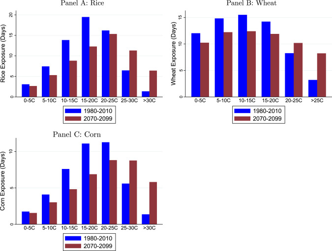

Fig. 3. Temperature Exposures for Rice, Wheat, and Corn between 1980–2010 and 2070–2099. *Notes*: The “1980–2010” bars and the “2070–2099” bars represent the exposure in days in each temperature category in the growing season for each crop over the periods 1980–2010 and 2070–2099, respectively. (For interpretation of the references to color in this figure caption, the reader is referred to the web version of this paper.)

For precipitation, following the literature, we use the cumulative precipitation and its quadratic in the growing season for each crop (Deschênes and Greenstone, 2007, Schlenker and Roberts, 2009, Welch et al., 2010, Chen et al., 2015). For additional climatic variables including relative humidity, wind speed, sunshine duration, and evaporation, we simply use the mean values during the growing season. We also discuss the nonlinear effect of those variables.

### Regression model

In order to assess the impacts of climate change on crop yield, we propose a model that incorporates a complete set of climatic variables in addition to temperature and precipitation. Let *c* index county and *t* index year. Crop yields *y*<sub>*ct*</sub> (kg/ha), which we take a natural log of in the regression, are related to climatic and other control variables by the following fixed-effect model<sup>26</sup>:(1)$lnyct=∫h̲h¯g(h)ϕct(h)dh+γ′Precct+δ′wct+αc+λt+εct.$

In this form, *g*(*h*) is the growth function of crop yields that depends on temperature *h*, while $h̲$ and $h¯$ are observed lower and upper bounds. The time distribution of temperature over the growing season in county *c* and year *t* is denoted as *ϕ*<sub>*ct*</sub>. In practice, we estimate *g*(*h*) using dummy variables for each 5 °C interval. The cumulative precipitation in the growing season and its quadratic are included in vector Prec<sub>*ct*</sub>. The vector of other climatic variables is designated by $wct$, including mean relative humidity, wind speed, sunshine duration, and evaporation during the growing season. We use county fixed effects *α*<sub>*c*</sub> to control for county-specific time invariant characteristics, such as geographic location, soil type, and soil quality. We use year fixed effects *λ*<sub>*t*</sub> to control for the shocks common to all counties in a given year. Examples of these shocks include changes in national agricultural policies, the introduction of new crop seeds, cost shocks such as fossil fuel and fertilizer prices, or technological shocks.<sup>27</sup> Lastly, *ε*<sub>*ct*</sub> is an unobservable error term with zero mean.

We estimate Eq. (1) separately for three crop species: rice, wheat, and corn. All regressions are weighted by crop-specific planted area to correct for heteroskedasticity associated with each county (Solon et al., 2013).<sup>28</sup> It is likely that the error terms are spatially correlated across counties. Therefore, we cluster the standard errors at the prefecture level to allow the counties within each prefecture to have spatially and temporally correlated standard errors.<sup>29</sup> Clustering the standard errors at a larger group is a common way to account for spatial correlations across smaller unit (Arellano, 1987, Conley, 1999, Wooldridge, 2003) and it is widely used in the literature (Welch et al., 2010, Fisher et al., 2012, Feng et al., 2013, Albouy et al., 2016, Burke and Emerick, 2016). Nonetheless, the results are also robust when we use Conley standard errors (Conley, 1999, Schlenker and Roberts, 2009) to account for spatial correlation.

### Identification

Since we are using a panel setting with county and year fixed effects, the coefficients of interests are identified from the plausibly exogenous variation in weather over time within counties after we adjust common shocks to all counties in a given year. Because weather fluctuations are generally random (Deschênes and Greenstone, 2007), we use plausibly exogenous inter-annual variations in weather conditions to identify the impact of climate change on agriculture.

However, previous studies include only temperature and precipitation. In such a case, the additional climatic variables will enter the error term *ε*<sub>*ct*</sub> if they are excluded from the regression. Those variables are typically correlated with temperature and precipitation, which violates the identification assumption. It is likely that the estimated coefficients of temperature are the combined effects of temperature and other climatic variables, instead of the marginal effect of temperature itself. The argument is similar for precipitation.

The direction and magnitude of the potential bias depends on the correlations between temperature and other climatic variables spatially and temporarily. Ideally, if the correlations between temperature and additional climatic variables are fixed over time and across space, those variables would simply be a function of temperature and omitted variable bias would be a minor issue. However, the correlation coefficients vary greatly across regions in both sign and magnitude. Additionally, the correlation may vary over time. For example, the correlation between temperature and humidity may vary over time because of changes in the frequency, intensity, and distribution of precipitation (Barreca, 2012).

## Empirical results

### Main results

Table 3 reports the regression results for rice. In column (1), we have temperature and precipitation only. We then add humidity, wind speed, sunshine duration, and evaporation one at a time. We report *F*-statistics for all climatic variables and those additional climatic variables. To compare the model fit, we report the percentage reduction in [BIC](https://www.sciencedirect.com/topics/economics-econometrics-and-finance/bayesian-information-criterion) relative to the model that only has county and year fixed effects. In the robustness check, we also use the [Akaike information criterion](https://www.sciencedirect.com/topics/economics-econometrics-and-finance/akaike-information-criterion) (AIC) and the conclusion still holds.<sup>30</sup>

Table 3. Regression results after controlling for additional climatic variables for rice.

| Variables Empty Cell 0–5 °C | Only Tem and pre (1) −0.0132 | Add humidity (2) −0.0148 | Add wind (3) −0.0040 | Add sunshine (4) −0.0070 | Add evaporation (5) −0.0067 |
| --- | --- | --- | --- | --- | --- |
| Empty Cell | (0.0091) | (0.0090) | (0.0087) | (0.0086) | (0.0085) |
| 5–10 °C | 0.0024 | 0.0036 | 0.0060 | 0.0046 | 0.0052 |
| Empty Cell | (0.0054) | (0.0054) | (0.0056) | (0.0055) | (0.0054) |
| 10–15 °C | 0.0110<sup>⁎</sup> | 0.0119<sup>⁎⁎</sup> | 0.0081 | 0.0042 | 0.0049 |
| Empty Cell | (0.0059) | (0.0059) | (0.0054) | (0.0053) | (0.0053) |
| 15–20 °C | 0.0032 | 0.0044 | 0.0028 | −0.0003 | −0.0000 |
| Empty Cell | (0.0051) | (0.0052) | (0.0050) | (0.0049) | (0.0048) |
| 20-25 °C | −0.0026 | −0.0018 | −0.0033 | −0.0096<sup>⁎</sup> | −0.0096<sup>⁎</sup> |
| Empty Cell | (0.0061) | (0.0061) | (0.0058) | (0.0052) | (0.0053) |
| 25–30 °C | 0.0174 | 0.0242<sup>⁎⁎</sup> | 0.0307<sup>⁎⁎⁎</sup> | 0.0287<sup>⁎⁎⁎</sup> | 0.0288<sup>⁎⁎⁎</sup> |
| Empty Cell | (0.0111) | (0.0110) | (0.0106) | (0.0109) | (0.0108) |
| $>$ 30 °C | −0.0734<sup>⁎⁎⁎</sup> | −0.0701<sup>⁎⁎⁎</sup> | −0.0678<sup>⁎⁎⁎</sup> | −0.0778<sup>⁎⁎⁎</sup> | −0.0767<sup>⁎⁎⁎</sup> |
| Empty Cell | (0.0145) | (0.0153) | (0.0134) | (0.0128) | (0.0129) |
| Precipitation | −0.0077<sup>⁎⁎⁎</sup> | −0.0084<sup>⁎⁎⁎</sup> | −0.0073<sup>⁎⁎⁎</sup> | −0.0063<sup>⁎⁎⁎</sup> | −0.0065<sup>⁎⁎⁎</sup> |
| Empty Cell | (0.0020) | (0.0021) | (0.0020) | (0.0020) | (0.0020) |
| Precipitation<sup>2</sup> | 3.45e−05<sup>⁎⁎⁎</sup> | 3.74e−05<sup>⁎⁎⁎</sup> | 3.27e−05<sup>⁎⁎⁎</sup> | 2.79e−05<sup>⁎⁎⁎</sup> | 2.89e−05<sup>⁎⁎⁎</sup> |
| Empty Cell | (1.06e−05) | (1.09e−05) | (1.08e−05) | (1.06e−05) | (1.07e−05) |
| Humidity | — | 0.0070<sup>⁎⁎</sup> | 0.0055<sup>⁎</sup> | 0.0075<sup>⁎⁎</sup> | 0.0075<sup>⁎⁎</sup> |
| Empty Cell |  | (0.0030) | (0.0028) | (0.0030) | (0.0030) |
| Wind | — | — | −0.1447<sup>⁎⁎⁎</sup> | −0.1424<sup>⁎⁎⁎</sup> | −0.1451<sup>⁎⁎⁎</sup> |
| Empty Cell |  |  | (0.0265) | (0.0267) | (0.0264) |
| Sunshine | — | — | — | 0.0593<sup>⁎⁎⁎</sup> | 0.0610<sup>⁎⁎⁎</sup> |
| Empty Cell |  |  |  | (0.0174) | (0.0173) |
| Evaporation | — | — | — | — | −0.0078 |
| Empty Cell |  |  |  |  | (0.0067) |
| Observations | 8577 | 8577 | 8577 | 8577 | 8577 |
| *R*-squared | 0.6987 | 0.6997 | 0.7072 | 0.7100 | 0.7103 |
| *F*-statistic (all clim. vars.) | 7.40<sup>⁎⁎⁎</sup> | 8.19<sup>⁎⁎⁎</sup> | 9.00<sup>⁎⁎⁎</sup> | 9.56<sup>⁎⁎⁎</sup> | 9.26<sup>⁎⁎⁎</sup> |
| *F*-statistic (addi. clim. vars.) | — | 5.23<sup>⁎⁎</sup> | 18.69<sup>⁎⁎⁎</sup> | 15.92<sup>⁎⁎⁎</sup> | 12.74<sup>⁎⁎⁎</sup> |
| Percent reduction in BIC (%) | 7.95 | 8.37 | 13.03 | 14.70 | 14.68 |

*Notes*: The dependent variable is the log yields of rice. Regression models are estimated using Eq. (1). Regression models are weighted by the planted area and include county and year fixed effects. Standard errors are clustered at the prefecture level. The percent reduction in BIC is relative to the model with only county and year fixed effects.

**⁎**

$p<0.10$.

**⁎⁎**

$p<0.05$.

**⁎⁎⁎**

$p<0.01$.

In terms of additional climatic variables, humidity is beneficial for rice, and the effect is both statistically and economically significant. The point estimate in column (5) suggests that a 1% increase in humidity increases rice yields by 0.75%. Wind speed, on the other hand, has significantly negative effects on rice yields. When wind speed increases by 1 meter per second, rice yields decrease by 14.51%. Sunshine duration has positive effects on rice yields. The point estimate in column (5) suggests that 1 additional hour of sunshine duration increases rice yields by 6.10%. The effect of evaporation, however, is statistically insignificant.

Overall, our results show that it is important to control for those additional climatic variables. On the one hand, the majority of these additional climatic variables are significant at individual level. On the other hand, the *F*-statistic of additional climatic variables are jointly significant, rejecting the null hypothesis that the joint impacts of additional climatic variables are equal to zero.

Furthermore, including additional climatic variables also significantly improves the model fit. Relative to the model with no climatic variables, adding temperature and precipitation decreases the BIC by 7.95%. When we add humidity, the BIC is reduced by 8.37%, and keeps reducing when we further add wind speed and sunshine duration. The full model decreases the BIC by 14.68%, and the change is twice as much, when compared to the restricted model, which indicates that those additional climatic variables are just as important as temperature and precipitation in terms of model fitting.

As shown in Fig. 1 and Table 2, climate change is likely to increase both humidity and wind speed. Therefore, ignoring additional climatic variables may bias the climate prediction. On the one hand, higher humidity is expected to increase rice yields, and thus the increased humidity induced by climate change may partially compensate the negative effects of high temperatures. This suggests that omitting humidity may overestimate the cost of climate change on rice yields. On the other hand, higher wind speed tends to decrease rice yields, and thus a windier climate is likely to be harmful for rice. Thus, ignoring wind speed is likely to underestimate the cost of climate change. As a result, the size and direction of the bias is essentially an empirical question.

Table 4, Table 5 further report the regression results for wheat and corn. Generally, we find similar conclusions with rice. For wheat, temperatures above 25 °C have significantly negative effects. The effect of precipitation is generally insignificant. The effect of humidity is significantly positive. The point estimate in column (5) in Table 4 suggests that 1% increase in humidity increases wheat yields by 0.96%. On the contrary, wind speed has significantly negative effects on wheat yields. We find that if wind speed increases by 1 meter per second, wheat yields decrease by 13.91%. Because climate change is expected to increase both humidity and wind speed (Fig. 1 and Table 2), ignoring those two variables may bias the climate prediction. The effects of sunshine duration and evaporation are statistically insignificant in general.

Table 4. Regression results after controlling for additional climatic variables for wheat.

| Variables Empty Cell 0–5 °C | Only tem and pre (1) −0.0064 | Add humidity (2) −0.0096 | Add wind (3) −0.0074 | Add sunshine (4) −0.0077 | Add evaporation (5) −0.0068 |
| --- | --- | --- | --- | --- | --- |
| Empty Cell | (0.0068) | (0.0064) | (0.0063) | (0.0063) | (0.0064) |
| 5–10 °C | 0.0028 | 0.0044 | 0.0054 | 0.0058 | 0.0059 |
| Empty Cell | (0.0053) | (0.0052) | (0.0052) | (0.0049) | (0.0049) |
| 10–15 °C | −0.0399<sup>⁎⁎⁎</sup> | −0.0386<sup>⁎⁎⁎</sup> | −0.0384<sup>⁎⁎⁎</sup> | −0.0378<sup>⁎⁎⁎</sup> | −0.0376<sup>⁎⁎⁎</sup> |
| Empty Cell | (0.0084) | (0.0081) | (0.0081) | (0.0078) | (0.0077) |
| 15–20 °C | −0.0272<sup>⁎⁎⁎</sup> | −0.0270<sup>⁎⁎⁎</sup> | −0.0280<sup>⁎⁎⁎</sup> | −0.0271<sup>⁎⁎⁎</sup> | −0.0273<sup>⁎⁎⁎</sup> |
| Empty Cell | (0.0083) | (0.0081) | (0.0080) | (0.0081) | (0.0080) |
| 20–25 °C | −0.0363<sup>⁎⁎⁎</sup> | −0.0272<sup>⁎⁎</sup> | −0.0323<sup>⁎⁎⁎</sup> | −0.0317<sup>⁎⁎</sup> | −0.0311<sup>⁎⁎</sup> |
| Empty Cell | (0.0119) | (0.0120) | (0.0123) | (0.0123) | (0.0124) |
| $>$ 25 °C | −0.0616<sup>⁎⁎⁎</sup> | −0.0558<sup>⁎⁎⁎</sup> | −0.0469<sup>⁎⁎⁎</sup> | −0.0458<sup>⁎⁎⁎</sup> | −0.0476<sup>⁎⁎⁎</sup> |
| Empty Cell | (0.0152) | (0.0151) | (0.0150) | (0.0151) | (0.0155) |
| Precipitation | −0.0024 | −0.0032 | −0.0028 | −0.0028 | −0.0031 |
| Empty Cell | (0.0019) | (0.0020) | (0.0019) | (0.0020) | (0.0019) |
| Precipitation<sup>2</sup> | 2.89e−05<sup>⁎</sup> | 3.36e−05<sup>⁎⁎</sup> | 2.99e−05<sup>⁎</sup> | 2.95e−05<sup>⁎</sup> | 3.16e−05<sup>⁎⁎</sup> |
| Empty Cell | (1.56e−05) | (1.62e−05) | (1.60e−05) | (1.61e−05) | −1.59E−05 |
| Humidity | — | 0.0127<sup>⁎⁎⁎</sup> | 0.0107<sup>⁎⁎⁎</sup> | 0.0103<sup>⁎⁎</sup> | 0.0096<sup>⁎⁎</sup> |
| Empty Cell |  | (0.0042) | (0.0041) | (0.0042) | (0.0043) |
| Wind | — | — | −0.1335<sup>⁎⁎⁎</sup> | −0.1329<sup>⁎⁎⁎</sup> | −0.1391<sup>⁎⁎⁎</sup> |
| Empty Cell |  |  | (0.0393) | (0.0392) | (0.0392) |
| Sunshine | — | — | — | −0.0118 | −0.0091 |
| Empty Cell |  |  |  | (0.0252) | (0.0255) |
| Evaporation | — | — | — | — | −0.0203 |
| Empty Cell |  |  |  |  | (0.0167) |
| Observations | 13,407 | 13,407 | 13,407 | 13,407 | 13,407 |
| *R*-squared | 0.8203 | 0.8217 | 0.8236 | 0.8236 | 0.8239 |
| *F*-statistic (All Clim. Vars.) | 9.92<sup>⁎⁎⁎</sup> | 10.72<sup>⁎⁎⁎</sup> | 10.34<sup>⁎⁎⁎</sup> | 9.45<sup>⁎⁎⁎</sup> | 9.47<sup>⁎⁎⁎</sup> |
| *F*-statistic (Addi. Clim. Vars.) | — | 8.97<sup>⁎⁎⁎</sup> | 10.66<sup>⁎⁎⁎</sup> | 7.82<sup>⁎⁎⁎</sup> | 7.18<sup>⁎⁎⁎</sup> |
| Percent reduction in BIC | 39.82 | 44.35 | 50.41 | 50.09 | 50.54 |

*Notes*: The dependent variable is the log yields of wheat. Regression models are estimated using Eq. (1). Regression models are weighted by the planted area and include county and year fixed effects. Standard errors are clustered at the prefecture level. The percent reduction in BIC is relative to the model with only county and year fixed effects.

**⁎**

$p<0.10$.

**⁎⁎**

$p<0.05$.

**⁎⁎⁎**

$p<0.01$.

Table 5. Regression results after controlling for additional climatic variables for corn.

| Variables Empty Cell | Only Tem and Pre (1) | Add Humidity (2) | Add Wind (3) | Add Sunshine (4) | Add Evaporation (5) |
| --- | --- | --- | --- | --- | --- |
| 0–5 °C | −0.0165 | −0.0164 | −0.0136 | −0.0188 | −0.0187 |
| Empty Cell | (0.0192) | (0.0191) | (0.0194) | (0.0195) | (0.0195) |
| 5–10 °C | 0.0072 | 0.0084 | 0.0080 | 0.0055 | 0.0051 |
| Empty Cell | (0.0094) | (0.0094) | (0.0094) | (0.0096) | (0.0099) |
| 10–15 °C | 0.0064 | 0.0075 | 0.0055 | −0.0002 | −0.0008 |
| Empty Cell | (0.0082) | (0.0084) | (0.0082) | (0.0086) | (0.0082) |
| 15–20 °C | 0.0198<sup>⁎⁎</sup> | 0.0215<sup>⁎⁎</sup> | 0.0201<sup>⁎⁎</sup> | 0.0135 | 0.0131 |
| Empty Cell | (0.0086) | (0.0085) | (0.0086) | (0.0085) | (0.0085) |
| 20–25 °C | −0.0418<sup>⁎⁎⁎</sup> | −0.0420<sup>⁎⁎⁎</sup> | −0.0448<sup>⁎⁎⁎</sup> | −0.0535<sup>⁎⁎⁎</sup> | −0.0544<sup>⁎⁎⁎</sup> |
| Empty Cell | (0.0121) | (0.0122) | (0.0119) | (0.0123) | (0.0131) |
| 25–30 °C | −0.0202 | −0.0128 | −0.0101 | −0.0133 | −0.0132 |
| Empty Cell | (0.0221) | (0.0225) | (0.0224) | (0.0221) | (0.0221) |
| $>$ 30 °C | −0.0802<sup>⁎⁎</sup> | −0.0729<sup>⁎⁎</sup> | −0.0738<sup>⁎⁎</sup> | −0.0879<sup>⁎⁎</sup> | −0.0884<sup>⁎⁎</sup> |
| Empty Cell | (0.0343) | (0.0350) | (0.0352) | (0.0367) | (0.0370) |
| Precipitation | 0.0131<sup>⁎⁎⁎</sup> | 0.0124<sup>⁎⁎⁎</sup> | 0.0124<sup>⁎⁎⁎</sup> | 0.0127<sup>⁎⁎⁎</sup> | 0.0127<sup>⁎⁎⁎</sup> |
| Empty Cell | (0.0025) | (0.0026) | (0.0025) | (0.0025) | (0.0025) |
| Precipitation<sup>2</sup> | −0.0001<sup>⁎⁎⁎</sup> | −0.0001<sup>⁎⁎⁎</sup> | −0.0001<sup>⁎⁎⁎</sup> | −0.0001<sup>⁎⁎⁎</sup> | −0.0001<sup>⁎⁎⁎</sup> |
| Empty Cell | (0.0000) | (0.0000) | (0.0000) | (0.0000) | (0.0000) |
| Humidity | — | 0.0054<sup>⁎</sup> | 0.0050<sup>⁎</sup> | 0.0061<sup>⁎⁎</sup> | 0.0061<sup>⁎⁎</sup> |
| Empty Cell |  | (0.0028) | (0.0028) | (0.0028) | (0.0027) |
| Wind | — | — | −0.0410 | −0.0413 | −0.0416<sup>⁎</sup> |
| Empty Cell |  |  | (0.0263) | (0.0252) | (0.0252) |
| Sunshine | — | — | — | 0.0395<sup>⁎⁎⁎</sup> | 0.0384<sup>⁎⁎</sup> |
| Empty Cell |  |  |  | (0.0149) | (0.0154) |
| Evaporation | — | — | — | — | 0.0019 |
| Empty Cell |  |  |  |  | (0.0067) |
| Observations | 16,840 | 16,840 | 16,840 | 16,840 | 16,840 |
| *R*-squared | 0.6672 | 0.6675 | 0.6678 | 0.6688 | 0.6688 |
| *F*-statistic (all clim. vars.) | 12.06<sup>⁎⁎⁎</sup> | 17.69<sup>⁎⁎⁎</sup> | 15.72<sup>⁎⁎⁎</sup> | 15.63<sup>⁎⁎⁎</sup> | 14.53<sup>⁎⁎⁎</sup> |
| *F*-statistic (addi. clim. vars.) | — | 3.65<sup>⁎</sup> | 2.47<sup>⁎</sup> | 3.88<sup>⁎⁎⁎</sup> | 3.00<sup>⁎⁎</sup> |
| Percent reduction in BIC | 27.03 | 27.16 | 27.29 | 28.05 | 27.88 |

*Notes*: The dependent variable is the log yields of corn. Regression models are estimated using Eq. (1). Regression models are weighted by the planted area and include county and year fixed effects. Standard errors are clustered at the prefecture level. The percent reduction in BIC is relative to the model with only county and year fixed effects.

**⁎**

$p<0.10$.

**⁎⁎**

$p<0.05$.

**⁎⁎⁎**

$p<0.01$.

The additional climatic variables are also jointly significant at the 1% level in explaining the variations in wheat yields. Furthermore, including these variables significantly improves the model fit. For example, the BIC is reduced from 39.82% to 44.35% when we add humidity in addition to temperature and precipitation. The BIC is further reduced to 50.41% when we include wind speed. However, the BIC slightly increases when we include sunshine duration but decreases to 50.54 when we add evaporation. In general,the full model reduces the BIC by around 10% relative to the restricted model.

As for corn, temperatures above 30 °C have significantly negative effects. The effect of precipitation is significantly positive, while its quadratic is significantly negative. This indicates an inverted U-shaped relationship between precipitation and corn yields with optimal precipitation at 63.5 centimeters. For additional climatic variables, humidity generally has significantly positive effects on corn yields. We find that a 1% increase in humidity increases corn yields by 0.61%. The effect of wind speed on corn yields is negative, but the statistical significance is weak. This result shows that when average wind speed increases by 1 meter per second, corn yields decrease by 4.16%. The magnitude is also smaller compared with rice (−14.51%) and wheat (−13.91%). In terms of sunshine duration, its effect on corn is both economically and statistically significant. When sunshine duration increases by 1 hour, corn yields increase by 3.84%. As for evaporation, the effect is statistically insignificant.

Including additional climatic variables also improves the model fit for corn. For example, when humidity is included, the BIC is decreased from 27.03% to 27.16%, and keeps decreasing when wind speed and sunshine duration are included. However, the BIC slightly increases when we include evaporation. Comparing column (1) and column (5), the BIC is reduced from 27.03% to 27.88%. The change is relatively small compared with rice and wheat.

Overall, the results demonstrate the importance of additional climatic variables other than temperature in three ways. First, the majority of those additional climatic variables are both economically and statistically significant. Second, including additional climatic variables largely improves the model fit for rice and wheat. Third, because those additional climatic variables are important for crop growth, ignoring the changes of those variables is likely to bias the climate prediction.

### Measuring nonlinear effects of temperature using growing degree days

In the previous section, we use exposure in days within each 5 °C interval to measure the nonlinear effects of temperature. This method assumes a constant growth rate within each bin, and thus may not be able to linearize the effects of extremely high temperatures. Therefore, in this section, we use the agronomic concept of degree days, to better extrapolate the negative effects of extremely high temperatures. We calculate the growing degree days (GDD) following Schlenker and Roberts (2009).

Table 6 presents the main regression results using the GDD method. Columns (1a), (2a), and (3a) are the baseline results for rice, wheat, and corn, in which we only have GDD and precipitation. In columns (1b), (2b), and (3b), we add additional climatic variables, including humidity, wind speed, sunshine duration, and evaporation.

Table 6. Measure Nonlinear Effects of Temperature using GDD.

| Variables Empty Cell | Rice Only tem and pre (1a) | Rice Full variables (1b) | Wheat Only tem and pre (2a) | Wheat Full variables (2b) | Corn Only tem and pre (3a) | Corn Full variables (3b) |
| --- | --- | --- | --- | --- | --- | --- |
| 0–5 °C | 0.0012 | 0.0012 | 0.0003 | −0.0003 | 0.0043<sup>⁎⁎⁎</sup> | 0.0046<sup>⁎⁎⁎</sup> |
| Empty Cell | (0.0012) | (0.0011) | (0.0004) | (0.0004) | (0.0016) | (0.0017) |
| 5–10 °C | 0.0005 | 0.0008 | 0.0011<sup>⁎⁎</sup> | 0.0017<sup>⁎⁎⁎</sup> | −0.0030<sup>⁎⁎</sup> | −0.0032<sup>⁎⁎</sup> |
| Empty Cell | (0.0009) | (0.0010) | (0.0006) | (0.0005) | (0.0015) | (0.0016) |
| 10–15 °C | −0.0003 | −0.0010<sup>⁎</sup> | −0.0027<sup>⁎⁎⁎</sup> | −0.0032<sup>⁎⁎⁎</sup> | 0.0015 | 0.0015 |
| Empty Cell | (0.0006) | (0.0005) | (0.0007) | (0.0007) | (0.0010) | (0.0010) |
| 15–20 °C | 0.0004 | 0.0006 | 0.0000 | 0.0006 | 0.0010 | 0.0008 |
| Empty Cell | (0.0004) | (0.0004) | (0.0008) | (0.0008) | (0.0008) | (0.0008) |
| 20–25 °C | −0.0010<sup>⁎⁎</sup> | −0.0011<sup>⁎⁎</sup> | −0.0003 | −0.0002 | −0.0035<sup>⁎⁎⁎</sup> | −0.0035<sup>⁎⁎⁎</sup> |
| Empty Cell | (0.0004) | (0.0005) | (0.0010) | (0.0010) | (0.0009) | (0.0009) |
| 25–30 °C | 0.0015<sup>⁎⁎⁎</sup> | 0.0019<sup>⁎⁎⁎</sup> | −0.0025<sup>⁎⁎⁎</sup> | −0.0018<sup>⁎⁎</sup> | 0.0001 | 0.0003 |
| ($>$ 25 °C for wheat) | (0.0006) | (0.0006) | (0.0009) | (0.0009) | (0.0011) | (0.0011) |
| $>$ 30 °C | −0.0035<sup>⁎⁎⁎</sup> | −0.0033<sup>⁎⁎⁎</sup> | — | — | −0.0021<sup>⁎⁎</sup> | −0.0022<sup>⁎⁎</sup> |
| Empty Cell | (0.0005) | (0.0005) | — | — | (0.0009) | (0.0009) |
| Precipitation | −0.0076<sup>⁎⁎⁎</sup> | −0.0059<sup>⁎⁎⁎</sup> | −0.0028 | −0.0029 | 0.0139<sup>⁎⁎⁎</sup> | 0.0143<sup>⁎⁎⁎</sup> |
| Empty Cell | (0.0020) | (0.0020) | (0.0019) | (0.0019) | (0.0021) | (0.0022) |
| Precipitation<sup>2</sup> | 3.39e−05<sup>⁎⁎⁎</sup> | 2.69e−05<sup>⁎⁎</sup> | 3.25e−05<sup>⁎⁎</sup> | 3.13e−05<sup>⁎</sup> | −0.0001<sup>⁎⁎⁎</sup> | −0.0001<sup>⁎⁎⁎</sup> |
| Empty Cell | (1.08e−05) | (1.07e−05) | (1.58e−05) | (1.60e−05) | (0.0000) | (0.0000) |
| Humidity | — | 0.0072<sup>⁎⁎</sup> | — | 0.0088<sup>⁎⁎</sup> | — | 0.0039<sup>⁎</sup> |
| Empty Cell | — | (0.0030) | — | (0.0043) | — | (0.0022) |
| Wind | — | −0.1489<sup>⁎⁎⁎</sup> | — | −0.1526<sup>⁎⁎⁎</sup> | — | −0.0220 |
| Empty Cell | — | (0.0261) | — | (0.0396) | — | (0.0211) |
| Sunshine | — | 0.0619<sup>⁎⁎⁎</sup> | — | −0.0519<sup>⁎</sup> | — | 0.0362<sup>⁎⁎⁎</sup> |
| Empty Cell | — | (0.0180) | — | (0.0277) | — | (0.0097) |
| Evaporation | — | −0.0063 | — | −0.0172 | — | −0.0003 |
| Empty Cell | — | (0.0067) | — | (0.0170) | — | (0.0045) |
| Observations | 8577 | 8577 | 13,407 | 13,407 | 16,840 | 16,840 |
| *R*-squared | 0.6990 | 0.7113 | 0.8170 | 0.8218 | 0.6652 | 0.6664 |
| Percent reduction in BIC | 8.13 | 15.35 | 28.58 | 43.30 | 25.16 | 25.59 |

*Notes*: The dependent variables are the log yields of each crop. Regression models are estimated using Eq. (1). Regression models are weighted by the planted area and include county and year fixed effects. Standard errors are clustered at the prefecture level. The percent reduction in BIC is relative to the model with only county and year fixed effects.

**⁎**

$p<0.10$.

**⁎⁎**

$p<0.05$.

**⁎⁎⁎**

$p<0.01$.

Overall, the results are robust when we measure the nonlinear effects of temperature using GDD. Extremely high temperatures, above 30 °C for rice and corn, and above 25 °C for wheat, have significantly negative effects on crop yields. When we add additional climatic variables, the negative effects of extremely high temperatures become smaller for rice and wheat. Those additional climatic variables, especially humidity and wind speed, exhibit significant impacts on crop yields. In addition, including additional climatic variables also largely improves the model fit. For example, the percent reduction in BIC changes from 8.13 to 15.35 for rice and from 28.58 to 43.30 for wheat. Because BIC reduction is higher when we measure temperature using exposures than using GDD for wheat and corn, we keep using exposures as the main specification.

### Nonlinear effects of additional climatic variables

In the previous section, we use the mean value during the growing season for each additional climatic variable. In this section, we consider their nonlinear effects by adding the quadratics. Table 7 reports the main regression results. Due to space limitations, we only report the effects of the highest temperature range and those additional climatic variables. Columns (1a), (2a), and (3a) are the baseline results for rice, wheat, and corn, in which only the mean value during the growing season is included. In columns (1b), (2b), and (3b), we add the quadratics for each additional climatic variable.

Table 7. Nonlinear effects of additional climatic variables.

| Variables Empty Cell | Rice Baseline (1a) | Rice Add quadratics (1b) | Wheat Baseline (2a) | Wheat Add quadratics (2b) | Corn Baseline (3a) | Corn Add quadratics (3b) |
| --- | --- | --- | --- | --- | --- | --- |
| $>$ 30 °C ($>$ 25 °C for Wheat) | −0.0767<sup>⁎⁎⁎</sup> | −0.0720<sup>⁎⁎⁎</sup> | −0.0476<sup>⁎⁎⁎</sup> | −0.0483<sup>⁎⁎⁎</sup> | −0.0884<sup>⁎⁎</sup> | −0.0786<sup>⁎⁎</sup> |
| Empty Cell | (0.0129) | (0.0124) | (0.0155) | (0.0152) | (0.0370) | (0.0356) |
| Humidity | 0.0075<sup>⁎⁎</sup> | 0.0107 | 0.0096<sup>⁎⁎</sup> | 0.0109 | 0.0061<sup>⁎⁎</sup> | 0.0134 |
| Empty Cell | (0.0030) | (0.0224) | (0.0043) | (0.0257) | (0.0027) | (0.0220) |
| Humidity<sup>2</sup> | — | −0.0000 | — | −0.0000 | — | −0.0001 |
| Empty Cell | — | (0.0002) | — | (0.0002) | — | (0.0002) |
| Wind | −0.1451<sup>⁎⁎⁎</sup> | 0.0751 | −0.1391<sup>⁎⁎⁎</sup> | −0.5202<sup>⁎⁎⁎</sup> | −0.0416<sup>⁎</sup> | 0.0797 |
| Empty Cell | (0.0264) | (0.0864) | (0.0392) | (0.0987) | (0.0252) | (0.0917) |
| Wind<sup>2</sup> | — | −0.0377<sup>⁎</sup> | — | 0.0730<sup>⁎⁎⁎</sup> | — | −0.0212 |
| Empty Cell | — | (0.0201) | — | (0.0144) | — | (0.0176) |
| Sunshine | 0.0610<sup>⁎⁎⁎</sup> | 0.0248 | −0.0091 | 0.4145<sup>⁎⁎⁎</sup> | 0.0384<sup>⁎⁎</sup> | −0.0061 |
| Empty Cell | (0.0173) | (0.0585) | (0.0255) | (0.1036) | (0.0154) | (0.0496) |
| Sunshine<sup>2</sup> | — | 0.0015 | — | −0.0362<sup>⁎⁎⁎</sup> | — | 0.0026 |
| Empty Cell | — | (0.0047) | — | (0.0085) | — | (0.0042) |
| Evaporation | −0.0078 | 0.0455<sup>⁎⁎⁎</sup> | −0.0203 | 0.0125 | 0.0019 | 0.0326<sup>⁎⁎</sup> |
| Empty Cell | (0.0067) | (0.0140) | (0.0167) | (0.0260) | (0.0067) | (0.0129) |
| Evaporation<sup>2</sup> | — | −0.0087<sup>⁎⁎⁎</sup> | — | −0.0082<sup>⁎</sup> | — | −0.0037<sup>⁎⁎⁎</sup> |
| Empty Cell | — | (0.0019) | — | (0.0049) | — | (0.0012) |
| Observations | 8577 | 8577 | 13,407 | 13,407 | 16,840 | 16,840 |
| *R*-squared | 0.7103 | 0.7163 | 0.8239 | 0.8290 | 0.6688 | 0.6702 |
| Percent reduction in BIC (%) | 14.68 | 17.94 | 50.54 | 66.98 | 27.88 | 28.51 |

*Notes*: The dependent variables are the log yields of each crop. Regression models are estimated using Eq. (1). Regression models are weighted by the planted area and include county and year fixed effects. Standard errors are clustered at the prefecture level. The percent reduction in BIC is relative to the model with only county and year fixed effects. Due to space limitations, we only report the effects of the highest temperature range and additional climatic variables.

**⁎**

$p<0.10$.

**⁎⁎**

$p<0.05$.

**⁎⁎⁎**

$p<0.01$.

In terms of sunshine duration, when we have only linear term, the effect is significantly positive for rice and corn, but becomes insignificantly when we add the quadratic, indicating a positive linear relationship between sunshine duration and rice and corn yields. For wheat, the linear term only is statistically insignificant, but becomes significantly positive when adding a quadratic term, and the quadratic is significantly negative. This shows that the effect of sunshine duration on wheat yields exhibits an inverted U-shaped relationship, with the optimal sunshine duration at 5.73 hours.

For evaporation, the effect is generally insignificant when we have only linear term for all three crops. However, the linear term becomes significantly positive when we add the quadratic for rice and corn, and the quadratic remains significantly negative. The results indicate inverted U-shaped relationships between evaporation and rice and corn yields, with the optimal evaporation at 2.61 millimeters for rice and 4.41 millimeters for corn. The effect of evaporation on wheat is generally insignificant.

Including quadratics also improves the model fit. For example, the BIC is reduced from 14.68% to 17.94% when we add the quadratics for rice. Similarly, when we include the quadratic, the BIC decreases from 50.54% to 66.98% for wheat, and from 27.88% to 28.51% for corn. However, since the effects of the two most important climatic variables–humidity and wind speed–are linear, we use the model with only linear term as the baseline.

### Irrigation

Irrigation plays a vital role in agriculture, as it artificially provides water for crop growth. Additionally, irrigation is an important adaptation strategy to climate change. Therefore, responses to weather shocks may vary when irrigation is controlled for. Since the data on real irrigation area are not available, we use irrigation ratio, defined as the effective irrigation area over the total planted area, as a proxy for irrigation. To address the endogeneity of irrigation ratio, following Chen et al. (2015), we use irrigation ratio in the previous year as the [instrumental variable](https://www.sciencedirect.com/topics/economics-econometrics-and-finance/instrumental-variables) for the current irrigation ratio. We obtain province-level effective irrigation area from the China's Statistical Yearbook.<sup>32</sup>

Table 8 reports the regression results when irrigation is controlled for. Due to space limitations, we only report the effects of the highest temperature ranges, additional climatic variables, and irrigation ratio. Columns (1a), (2a), ad (3a) are the baseline results, in which we do not control for irrigation. In columns (1a), (2b), and (3b), irrigation ratio is added. Since the data in several regions and years are missing, the number of observations falls when adding irrigation ratio. To make results comparable, we also drop the observations with missing irrigation share in baseline models.

Table 8. Effects of Irrigation.

| Variables Empty Cell | Rice Baseline (1a) | Rice Add Irrigation (1b) | Wheat Baseline (2a) | Wheat Add Irrigation (2b) | Corn Baseline (3a) | Corn Add Irrigation (3b) |
| --- | --- | --- | --- | --- | --- | --- |
| $>$ 30 °C ($>$ 25 °C for Wheat) | −0.0912<sup>⁎⁎⁎</sup> | −0.0897<sup>⁎⁎⁎</sup> | −0.0463<sup>⁎⁎⁎</sup> | −0.0445<sup>⁎⁎⁎</sup> | −0.1092<sup>⁎⁎⁎</sup> | −0.1068<sup>⁎⁎⁎</sup> |
| Empty Cell | (0.0150) | (0.0149) | (0.0159) | (0.0156) | (0.0387) | (0.0388) |
| Humidity | 0.0093<sup>⁎⁎⁎</sup> | 0.0092<sup>⁎⁎⁎</sup> | 0.0119<sup>⁎⁎⁎</sup> | 0.0124<sup>⁎⁎⁎</sup> | 0.0069<sup>⁎⁎</sup> | 0.0068<sup>⁎⁎</sup> |
| Empty Cell | (0.0033) | (0.0033) | (0.0046) | (0.0046) | (0.0031) | (0.0031) |
| Wind | −0.1413<sup>⁎⁎⁎</sup> | −0.1358<sup>⁎⁎⁎</sup> | −0.1360<sup>⁎⁎⁎</sup> | −0.1309<sup>⁎⁎⁎</sup> | −0.0477<sup>⁎</sup> | −0.0451<sup>⁎</sup> |
| Empty Cell | (0.0265) | (0.0258) | (0.0395) | (0.0400) | (0.0262) | (0.0258) |
| Sunshine | 0.0521<sup>⁎⁎⁎</sup> | 0.0495<sup>⁎⁎⁎</sup> | −0.0180 | −0.0129 | 0.0450<sup>⁎⁎⁎</sup> | 0.0425<sup>⁎⁎⁎</sup> |
| Empty Cell | (0.0177) | (0.0174) | (0.0259) | (0.0264) | (0.0158) | (0.0156) |
| Evaporation | −0.0060 | −0.0046 | −0.0143 | −0.0088 | 0.0068 | 0.0074 |
| Empty Cell | (0.0071) | (0.0071) | (0.0168) | (0.0159) | (0.0068) | (0.0068) |
| Irrigation ratio | — | 0.0373<sup>⁎</sup> | — | −0.2028 | — | 0.0489<sup>⁎</sup> |
| Empty Cell | — | (0.0196) | — | (0.1469) | — | (0.0251) |
| Observations | 7715 | 7715 | 12,003 | 12,003 | 15,027 | 15,027 |
| *R*-squared | 0.7069 | 0.7076 | 0.8257 | 0.8266 | 0.6678 | 0.6682 |
| Percent reduction in BIC (%) | 18.16 | 18.45 | 62.37 | 65.71 | 27.69 | 27.83 |

*Notes*: The dependent variables are the log yields of each crop. Regression models are estimated using Eq. (1). Regression models are weighted by the planted area and include county and year fixed effects. Irrigation ratio is defined as effective irrigation area over total planted area. Since the data in several regions and years are missing, the number of observations fall when adding irrigation ratio. Standard errors are clustered at the prefecture level. The percent reduction in BIC is relative to the model with only county and year fixed effects. Due to space limitations, we only report the effects of the highest temperature range and additional climatic variables.

**⁎**

$p<0.10$.

**⁎⁎**

$p<0.05$.

**⁎⁎⁎**

$p<0.01$.

In general, irrigation has positive effects on rice and corn yields, although the statistical significance is week. This is not surprising because of the low variation in province-level irrigation share. When we add irrigation, the effects of additional climatic variables change little. Furthermore, adding irrigation share only slightly improves the model fit.<sup>33</sup>

### Exploring humidity

Humidity is regarded as one of the key climatic variables for crop growth (Roberts et al., 2012, Lobell et al., 2013). We consistently find positive effects of humidity across crops. This section explores these effects in detail.

#### Measuring humidity using vapor pressure deficit (VPD)

Humidity essentially measures the amount of water in the air. In the baseline, we use relative humidity, which is defined as the ratio of the amount of water vapor in the air, compared to the maximum water vapor that the air can hold at the given temperature. Humidity can also be approximately measured using vapor pressure deficit (VPD), which is defined as the difference in vapor pressure between current temperature and dew point temperature. VPD is closely related with relative humidity, evaporation, evapotranspiration, and soil moisture. Following Roberts et al. (2012), we approximate each day's VPD using the following formula:(2)$VPD=0.6107(e(17.269Th237.3+Th)−e(17.269Tl237.3+Tl)),$where *T*<sub>*h*</sub> and *T*<sub>*l*</sub> are daily maximum and minimum temperatures respectively. We then calculate average VDP during the growing season of each crop.

Table 9 reports the regression results when we replace relative humidity with VPD. Due to space limitations, we only report the estimates of the highest temperature ranges and those additional climatic variables. In columns (1a), (2a), and (3a), we include temperature and precipitation only. In columns (1b), (2b), and (3b), we include a full set of climatic variables, in which we measure humidity using VPD.

Table 9. Measuring humidity using VPD.

| Variables Empty Cell $>$ 30 °C ($>$ 25 °C for Wheat) | Rice Only tem and pre (1a) −0.0734<sup>⁎⁎⁎</sup> | Rice Full variables (1b) −0.0927<sup>⁎⁎⁎</sup> | Wheat Only tem and pre (2a) −0.0616<sup>⁎⁎⁎</sup> | Wheat Full variables (2b) −0.0016 | Corn Only Tem and pre (3a) −0.0802<sup>⁎⁎</sup> | Corn Full variables (3b) −0.1038<sup>⁎⁎</sup> |
| --- | --- | --- | --- | --- | --- | --- |
| Empty Cell | (0.0145) | (0.0138) | (0.0152) | (0.0168) | (0.0343) | (0.0462) |
| VPD | — | 0.2370 | — | −1.4689<sup>⁎⁎⁎</sup> | — | 0.0749 |
| Empty Cell | — | (0.1927) | — | (0.2016) | — | (0.2768) |
| Wind | — | −0.1488<sup>⁎⁎⁎</sup> | — | −0.1192<sup>⁎⁎⁎</sup> | — | −0.0458<sup>⁎</sup> |
| Empty Cell | — | (0.0255) | — | (0.0382) | — | (0.0260) |
| Sunshine | — | 0.0511<sup>⁎⁎⁎</sup> | — | 0.0541<sup>⁎</sup> | — | 0.0341<sup>⁎⁎</sup> |
| Empty Cell | — | (0.0169) | — | (0.0287) | — | (0.0168) |
| Evaporation | — | −0.0085 | — | −0.0197 | — | 0.0013 |
| Empty Cell | — | (0.0067) | — | (0.0165) | — | (0.0066) |
| Observations | 8577 | 8577 | 13,407 | 13,407 | 16,840 | 16,840 |
| *R*-squared | 0.6987 | 0.7094 | 0.8203 | 0.8270 | 0.6672 | 0.6684 |
| Percent Reduction in BIC (%) | 7.95 | 14.13 | 39.82 | 61.45 | 27.03 | 27.51 |

*Notes*: The dependent variables are the log yields of each crop. Regression models are estimated using Eq. (1). Regression models are weighted by the planted area and include county and year fixed effects. Vapor deficit pressure (VPD) is calculated using daily maximum and minimum temperatures and is used to measure humidity. Standard errors are clustered at the prefecture level. The percent reduction in BIC is relative to the model with only county and year fixed effects. Due to space limitations, we only report the effects of the highest temperature range and additional climatic variables.

**⁎**

$p<0.10$.

**⁎⁎**

$p<0.05$.

**⁎⁎⁎**

$p<0.01$.

Overall, including additional climatic variables largely improves the model fit for rice and wheat. However, when humidity is measured using VPD, the effects are generally insignificant for rice and corn yields, but the effect on wheat yields is suspiciously large. We also find that the model fit using relative humidity is generally better than using VPD. This may be because we do not observe the actual VPD in the data; indeed, we use daily maximum and minimum temperatures to approximate VPD. Unlike Roberts et al. (2012), we have relatively sparse weather stations in China, which may cause measurement error in the approximation. Therefore, we use relative humidity in the baseline model.

#### Humidity in different time periods

The effect of humidity on corn yields may vary over time periods (Roberts et al., 2012). For example, in the warmest months, high humidity could slow down the transpiration of plants and help retain the water content for rice and corn (Hopkins and Hüner, 1995). As for wheat, high humidity during the coldest months may indicate adequate snow cover, which is supposed to be beneficial for wheat (Gusta and Chen, 1987).

Therefore, we add the average humidity during these critical periods in addition to seasonal average humidity. Following Roberts et al. (2012), we calculate average humidity during the two warmest months–July and August–for rice and corn. For wheat, since the growing season is typically from September to June, or from November to May, we calculate the average humidity during the two coldest months: January and February, which is also an indicator for snow cover.

Table 10 reports the regression results when we add month-specific humidity. Again, we only report the estimates for the highest temperature ranges and those additional climatic variables. Columns (1a), (2a), and (3a) are the baselines, in which we only have average humidity during the growing season. In columns (1b), (2b), and (3b), we add average humidity in July and August for rice and corn and average humidity in January and February for wheat, in addition to average humidity during the growing season. It is noted that the growing season for autumn corn is typically from August to November. Therefore, we lose the number of observations when we have average humidity between July and August. Thus, to make results comparable, we also drop autumn corn in the baseline model. This should have a limited impact on the conclusion since autumn corn only accounts for around 10% of total corn production in China.

Table 10. Humidity in different periods and interaction with temperature.

| Empty Cell $>$ 30 °C | Rice Baseline (1a) −0.0767<sup>⁎⁎⁎</sup> | Rice Add humidity in Jul–Aug (1b) −0.0835<sup>⁎⁎⁎</sup> | Rice Add interaction (1c) −0.0938 | Wheat Baseline (2a) −0.0476<sup>⁎⁎⁎</sup> | Wheat Add Humidity in Jan-Feb (2b) −0.0519<sup>⁎⁎⁎</sup> | Wheat Add interaction (2c) −0.0690<sup>⁎</sup> | Corn Baseline (3a) −0.1161<sup>⁎⁎</sup> | Corn Add humidity in Jul–Aug (3b) −0.1217<sup>⁎⁎</sup> | Corn Add interaction (3c) 0.1320 |
| --- | --- | --- | --- | --- | --- | --- | --- | --- | --- |
| ($>$ 25 °C for Wheat) | (0.0129) | (0.0132) | (0.0777) | (0.0155) | (0.0154) | (0.0378) | (0.0486) | (0.0482) | (0.1177) |
| Humidity | 0.0075<sup>⁎⁎</sup> | 0.0105<sup>⁎⁎</sup> | 0.0103<sup>⁎⁎</sup> | 0.0096<sup>⁎⁎</sup> | 0.0009 | 0.0010 | 0.0052 | −0.0068 | −0.0059 |
| Empty Cell | (0.0030) | (0.0046) | (0.0051) | (0.0043) | (0.0053) | (0.0053) | (0.0032) | (0.0047) | (0.0047) |
| Wind | −0.1451<sup>⁎⁎⁎</sup> | −0.1446<sup>⁎⁎⁎</sup> | −0.1446<sup>⁎⁎⁎</sup> | −0.1391<sup>⁎⁎⁎</sup> | −0.1361<sup>⁎⁎⁎</sup> | −0.1361<sup>⁎⁎⁎</sup> | −0.0286 | −0.0362 | −0.0365 |
| Empty Cell | (0.0264) | (0.0264) | (0.0263) | (0.0392) | (0.0389) | (0.0388) | (0.0287) | (0.0282) | (0.0283) |
| Sunshine | 0.0610<sup>⁎⁎⁎</sup> | 0.0607<sup>⁎⁎⁎</sup> | 0.0606<sup>⁎⁎⁎</sup> | −0.0091 | −0.0114 | −0.0138 | 0.0579<sup>⁎⁎⁎</sup> | 0.0598<sup>⁎⁎⁎</sup> | 0.0623<sup>⁎⁎⁎</sup> |
| Empty Cell | (0.0173) | (0.0174) | (0.0176) | (0.0255) | (0.0252) | (0.0262) | (0.0163) | (0.0163) | (0.0162) |
| Evaporation | −0.0078 | −0.0080 | −0.0081 | −0.0203 | −0.0213 | −0.0213 | 0.0025 | −0.0021 | −0.0009 |
| Empty Cell | (0.0067) | (0.0067) | (0.0067) | (0.0167) | (0.0167) | (0.0167) | (0.0071) | (0.0072) | (0.0071) |
| Humidity $Jul−Aug$ | — | −0.0034 | −0.0034 | — | 0.0067<sup>⁎⁎⁎</sup> | 0.0054<sup>⁎</sup> | — | 0.0152<sup>⁎⁎⁎</sup> | 0.0192<sup>⁎⁎⁎</sup> |
| (Humidity $Jan−Feb$ | — | (0.0031) | (0.0031) | — | (0.0021) | (0.0030) | — | (0.0038) | (0.0039) |
| for Wheat) | — | — | — | — |  | — | — | — | — |
| $>$ 30 °C $×$ Humidity | — | — | 0.0002 | — | — | 0.0003 | — | — | −0.0037<sup>⁎⁎⁎</sup> |
| ($>$ 25 °C $×$ Humidity | — | — | (0.0012) | — | — | (0.0005) | — | — | (0.0014) |
| for Wheat) | — | — | — | — | — | — | — | — | — |
| Observations | 8577 | 8577 | 8577 | 13,407 | 13,407 | 13,407 | 9,829 | 9,829 | 9,829 |
| *R*-squared | 0.7103 | 0.7105 | 0.7105 | 0.8239 | 0.8249 | 0.8249 | 0.6778 | 0.6808 | 0.6817 |
| Perc. Red. in BIC (%) | 14.68 | 14.65 | 14.45 | 50.54 | 53.60 | 53.27 | 34.40 | 37.61 | 38.39 |

*Notes*: The dependent variables are the log yields of each crop. Regression models are estimated using Eq. (1). Regression models are weighted by the planted area and include county and year fixed effects. For rice, we interact temperature above 30 °C with the seasonal average humidity because humidity in July and August is not statistically significant. However, for wheat and corn, we interact highest temperature range with month-specific humidity since humidity in those periods is statistically significant. Standard errors are clustered at the prefecture level. The percent reduction in BIC is relative to the model with only county and year fixed effects. Due to space limitations, we only report the effects of the highest temperature range, additional climatic variables, and the interactions.

**⁎**

$p<0.10$.

**⁎⁎**

$p<0.05$.

**⁎⁎⁎**

$p<0.01$.

For rice, when we add month-specific relative humidity, the seasonal average humidity still remains statistically significant. However, the effect of month-specific humidity is statistically insignificant. This indicates that humidity during the warmest months has limited effects on rice. This result is not surprising since rice is typically irrigated in China. Therefore, water content could still be retained even in the warmest months. We find that including average humidity in July and August also decreases the model fit.

For corn, however, we find large effects of humidity during the two warmest months. Generally, the effect of seasonal average humidity is statistically insignificant, but the average humidity during July and August has significantly positive effects on corn yields. The point estimate is particularly large: if average humidity in July and August increases by 1%, corn yields will increase by 1.52%. Given that humidity in July and August is likely to decrease under climate change (shown in Table 2), this suggests that omitting humidity in these critical months may underestimate the cost of climate change. Including month-specific humidity also greatly improves the model fit. Recall that the BIC is only reduced less than 1% when comparing the full model with the restricted model. However, the decreases are more than 3% when month-specific humidity is included.

For wheat, we also find large effects of month-specific humidity. In the baseline model in column (2a), average humidity in the growing season has significantly positive effects on wheat yields. However, when we add average humidity in January and February, seasonal average humidity becomes statistically insignificant. Instead, average humidity in January and February exhibits significantly positive effect on wheat yields. The point estimate suggests that when average humidity in January and February increases by 1%, wheat yields increase by 0.67%. This indicates that humidity in winter plays a critical role for wheat growth. In addition, including month-specific humidity also reduces the BIC by more than 3% relative to the model with seasonal average humidity only.

#### Interaction between humidity and temperature

It is possible that humidity and high temperatures have joint effects. For example, humidity could help crops retain water content through slowing down transpiration in hot days, but this process may be getting harder if there are more hot days. Therefore, in columns (1c), (2c), and (3c) in Table 10, we interact the highest temperature range with humidity. For rice, because month-specific humidity is statistically insignificant while seasonal average humidity is statistically significant, we interact the highest temperature range with the seasonal average humidity. For wheat and corn, we interact the highest temperature range with month-specific humidity because it has significant effects.

In general, the interaction between the highest temperature range and humidity is statistically insignificant for rice and wheat.<sup>34</sup> However, the interaction is statistically significant for corn. Given that the interaction is significantly negative and the effect of month-specific humidity is significantly positive, this suggests that the effect of humidity is limited when corn is exposed to more extremely high temperatures. In addition, including the interaction between the highest temperature range and month-specific humidity also improves the model fit by around 1%.

### Robustness checks

In the previous sections, we find that the majority of those additional climatic variables, especially humidity and wind speed, have both economically and statistically significant effects on crop yields. In addition, we find that including those variables improves the model fit, particularly for rice and wheat. Our baseline models include county and year fixed effects. The regression model is weighted by the planted area of each crop. In addition, we drop double and mixed cropped rice, spring wheat, and winter corn. To compare the model fit, we use the percent reduction in BIC relative to the model with only county and year fixed effects. In this section, we show the robustness of our major conclusion across various specifications.

Table 11 presents the robustness checks for each crop. We only report the estimates of the highest temperature ranges, additional climatic variables, and the percent reduction in BIC. In column (1), we replace year fixed effects with province-specific quadratic time trends. This allows us to control for smooth technology changes within each province. In column (2), we return to year fixed effects but do not weight the regression. In column (3), we include all types of rice, wheat, and corn in the analysis. In column (4), we use the Akaike information criterion (AIC) to measure model fit.

Table 11. Robustness checks.

| Empty Cell **Rice** | Time trend (1) Only tem and pre (1a) Empty Cell | Time trend (1) Full variables (1b) Empty Cell | No weighting (2) Only tem and pre (2a) Empty Cell | No weighting (2) Full variables (2b) Empty Cell | Full sample (3) Only tem and pre (3a) Empty Cell | Full sample (3) Full variables (3b) Empty Cell | Using AIC (4) Only tem and pre (4a) Empty Cell | Using AIC (4) Full variables (4b) Empty Cell |
| --- | --- | --- | --- | --- | --- | --- | --- | --- |
| $>$ 30 °C | −0.0703<sup>⁎⁎⁎</sup> | −0.0643<sup>⁎⁎⁎</sup> | −0.0903<sup>⁎⁎⁎</sup> | −0.0968<sup>⁎⁎⁎</sup> | −0.0549<sup>⁎⁎⁎</sup> | −0.0454<sup>⁎⁎⁎</sup> | −0.0734<sup>⁎⁎⁎</sup> | −0.0767<sup>⁎⁎⁎</sup> |
| Empty Cell | (0.0098) | (0.0099) | (0.0208) | (0.0206) | (0.0098) | (0.0100) | (0.0145) | (0.0129) |
| Hum. | — | 0.0105<sup>⁎⁎⁎</sup> | — | 0.0096<sup>⁎⁎⁎</sup> | — | 0.0120<sup>⁎⁎⁎</sup> | — | 0.0075<sup>⁎⁎</sup> |
| Empty Cell | — | (0.0021) | — | (0.0034) | — | (0.0021) | — | (0.0030) |
| Win. | — | −0.0738<sup>⁎⁎⁎</sup> | — | −0.1086<sup>⁎⁎⁎</sup> | — | −0.0555<sup>⁎⁎</sup> | — | −0.1451<sup>⁎⁎⁎</sup> |
| Empty Cell | — | (0.0238) | — | (0.0273) | — | (0.0220) | — | (0.0264) |
| Sun. | — | 0.0129 | — | 0.0847<sup>⁎⁎⁎</sup> | — | 0.0108 | — | 0.0610<sup>⁎⁎⁎</sup> |
| Empty Cell | — | (0.0154) | — | (0.0201) | — | (0.0132) | — | (0.0173) |
| Eva. | — | −0.0003 | — | −0.0172 | — | 0.0003 | — | −0.0078 |
| Empty Cell | — | (0.0045) | — | (0.0105) | — | (0.0046) | — | (0.0067) |
| BIC Red. | 3.19 | 5.04 | 13.55 | 36.64 | 4.61 | 6.08 | 9.23 | 16.49 |
| **Wheat** |  |  |  |  |  |  |  |  |
| $>$ 25 °C | −0.0652<sup>⁎⁎⁎</sup> | −0.0611<sup>⁎⁎⁎</sup> | −0.0457<sup>⁎⁎⁎</sup> | −0.0288<sup>⁎⁎</sup> | −0.0685<sup>⁎⁎⁎</sup> | −0.0512<sup>⁎⁎⁎</sup> | −0.0616<sup>⁎⁎⁎</sup> | −0.0476<sup>⁎⁎⁎</sup> |
| Empty Cell | (0.0105) | (0.0122) | (0.0127) | (0.0142) | (0.0125) | (0.0128) | (0.0152) | (0.0155) |
| Hum. | — | 0.0119<sup>⁎⁎⁎</sup> | — | 0.0171<sup>⁎⁎⁎</sup> | — | 0.0142<sup>⁎⁎⁎</sup> | — | 0.0096<sup>⁎⁎</sup> |
| Empty Cell | — | (0.0030) | — | (0.0043) | — | (0.0045) | — | (0.0043) |
| Win. | — | −0.0374 | — | −0.1061<sup>⁎⁎⁎</sup> | — | −0.1040<sup>⁎⁎⁎</sup> | — | −0.1391<sup>⁎⁎⁎</sup> |
| Empty Cell | — | (0.0313) | — | (0.0315) | — | (0.0339) | — | (0.0392) |
| Sun. | — | 0.0603<sup>⁎⁎</sup> | — | −0.0163 | — | −0.0027 | — | −0.0091 |
| Empty Cell | — | (0.0238) | — | (0.0288) | — | (0.0207) | — | (0.0255) |
| Eva. | — | −0.0248<sup>⁎⁎⁎</sup> | — | 0.0180<sup>⁎</sup> | — | −0.0010 | — | −0.0203 |
| Empty Cell | — | (0.0082) | — | (0.0104) | — | (0.0134) | — | (0.0167) |
| BIC Red. | 14.53 | 19.13 | 11.11 | 14.24 | 45.44 | 58.88 | 41.29 | 53.03 |
| **Corn** |  |  |  |  |  |  |  |  |
| $>$ 30 °C | −0.0736<sup>⁎⁎</sup> | −0.0596<sup>⁎</sup> | −0.0448<sup>⁎⁎</sup> | −0.0282 | −0.0832<sup>⁎⁎</sup> | −0.0942<sup>⁎⁎⁎</sup> | −0.0802<sup>⁎⁎</sup> | −0.0884<sup>⁎⁎</sup> |
| Empty Cell | (0.0324) | (0.0342) | (0.0225) | (0.0244) | (0.0337) | (0.0363) | (0.0343) | (0.0370) |
| Hum. | — | 0.0074<sup>⁎⁎⁎</sup> | — | 0.0104<sup>⁎⁎⁎</sup> | — | 0.0044<sup>⁎</sup> | — | 0.0061<sup>⁎⁎</sup> |
| Empty Cell | — | (0.0025) | — | (0.0028) | — | (0.0023) | — | (0.0027) |
| Win. | — | −0.0357 | — | −0.0696<sup>⁎⁎⁎</sup> | — | −0.0412<sup>⁎</sup> | — | −0.0416<sup>⁎</sup> |
| Empty Cell | — | (0.0243) | — | (0.0256) | — | (0.0232) | — | (0.0252) |
| Sun. | — | −0.0074 | — | 0.0166 | — | 0.0398<sup>⁎⁎⁎</sup> | — | 0.0384<sup>⁎⁎</sup> |
| Empty Cell | — | (0.0139) | — | (0.0173) | — | (0.0150) | — | (0.0154) |
| Eva. | — | −0.0026 | — | −0.0037 | — | 0.0001 | — | 0.0019 |
| Empty Cell | — | (0.0043) | — | (0.0057) | — | (0.0065) | — | (0.0067) |
| BIC Red. | 38.92 | 39.36 | 4.08 | 4.42 | 29.60 | 30.53 | 28.75 | 30.21 |

*Notes*: The dependent variables are the log yields of each crop. Regression models are estimated using Eq. (1). In columns (1a)–(1b), we replace year fixed effects with quadratic province time trends. In columns (2a)–(2b), we return to year fixed effects but do not weight the regression using planted area. In columns (3a)–(3b), we include all types of rice, wheat, and corn. In columns (4a)–(4b), we use [AIC](https://www.sciencedirect.com/topics/economics-econometrics-and-finance/akaike-information-criterion) to measure model fit. The percent reduction in BIC/AIC is relative to the model with only county and year fixed effects. Due to space limitations, we only report the effects of the highest temperature range and additional climatic variables.

**⁎**

$p<0.10$.

**⁎⁎**

$p<0.05$.

**⁎⁎⁎**

$p<0.01$.

Overall, the results are robust across different specifications. Humidity has significantly positive effects, while wind speed has significantly negative effects. Including additional climatic variables also improves the model fit, compared to the model with temperature and precipitation only.

## Climate change predictions

### Main results

This section predicts the impact of climate change on the yield of each crop.<sup>35</sup> The impact is calculated as follows. For simplicity, we start with only one climatic variable, say temperature, and then we have the equation(3)$lny=βTemp.$Assume that *y*<sub>0</sub> and *y*<sub>1</sub> are crop yields in periods 0 and 1. Similarly, assume that $Temp0$ and $Temp1$ are temperatures in two periods. Define $ΔTemp≡Temp1−Temp0$ and $Δy≡y1−y0$, we can calculate that(4)$Δyy0=eβΔTemp−1,$where $Δyy0$ is the percentage change of crop yield caused by climate change through changes in temperature.

If crop yield is a quadratic function of a climatic variable, say precipitation, we have(5)$lny=γ1Prec+γ2Prec2.$Similarly, we could calculate that(6)$Δyy0=e(γ1+2γ2Prec¯)ΔPrec−1,$where $Prec¯=(Prec1+Prec0)/2$ is the average precipitation.

In practice, first, we estimate regression coefficients for each climatic variable from Eq. (1). Second, we calculate $ΔTempct$, the differences between the past (1980–2010) and future (2070–2099) temperatures for each county. We then calculate the weighted average of temperature difference for a representative county, where the weights are the planted area of each county. Lastly, we use Eq. (4) to infer the impacts of climate change on crop yields through changes in temperature. Similarly, we calculate the impacts of climate change on crop yields through the effects of other climatic variables. Finally, we sum the impacts for all variables to calculate the total impacts of climate change on crop yields. Standard errors are calculated using the Delta method.

Table 12 reports the point estimates, standard errors, and 95% confidence intervals of the impacts of climate change on crop yields. In the first column, only temperature and precipitation are included in the regression. In column (2), we add the average humidity in the growing season. We then add month-specific humidity in column (3). In columns (4)–(6), we further add wind speed, sunshine duration, and evaporation. It is noted that HadCM3 A1FI scenario does not predict for changes in sunshine duration and evaporation. We believe this is a minor issue because their effects are relatively small compared with humidity and wind speed.

Table 12. Climate prediction.

| Empty Cell **Rice** Point Estimate (%) | Only tem and pre (1) Empty Cell −31.90 | Add humidity (2) Empty Cell −26.04 | Add Month-specific humidity (3) Empty Cell −26.42 | Add wind (4) Empty Cell −37.88 | Add sunshine (5) Empty Cell −35.74 | Add evaporation (6) Empty Cell −36.25 |
| --- | --- | --- | --- | --- | --- | --- |
| S.E. (%) | 12.01 | 11.95 | 11.43 | 11.45 | 10.84 | 10.75 |
| 95% C.I. (%) | [−55.44, −8.36] | [−49.46, −2.61] | [−48.82, −4.01] | [−60.33, −15.43] | [−56.99, −14.49] | [−57.33, −15.17] |
| **Wheat** |  |  |  |  |  |  |
| Point Estimate (%) | −11.85 | 3.14 | 0.29 | −15.26 | −15.60 | −18.26 |
| S.E. (%) | 10.46 | 10.48 | 10.01 | 11.64 | 11.65 | 12.13 |
| 95% C.I. (%) | [−32.35, 8.65] | [−17.40, 23.67] | [−19.33, 19.90] | [−38.07, 7.54] | [−38.44, 7.24] | [−42.04, 5.52] |
| **Corn** |  |  |  |  |  |  |
| Point Estimate (%) | −47.10 | −42.59 | −48.78 | −49.14 | −44.28 | −45.10 |
| S.E. (%) | 10.52 | 12.10 | 12.44 | 12.30 | 11.58 | 11.55 |
| 95% C.I. (%) | [−67.72, −26.47] | [−66.31, −18.87] | [−73.16, −24.40] | [−73.25, −25.03] | [−66.98, −21.57] | [−67.75, −22.46] |

*Notes*: The impacts of climate change on crop yields are calculated as follows. First, we estimate the impacts of climatic variables on crop yields using Eq. (1). Second, we calculate the difference between the past and the future climate for a representative county. The past climate is defined as the averages of climatic variables over the period 1980–2010, while the future climate is over the period 2070–2099. Lastly, we use the climate difference multiplied by the estimated coefficients to infer the impacts of climate change. Standard errors are calculated using the Delta method. In the first column, we only include temperature and precipitation in the regression model. In the subsequent columns, we further add the seasonal average humidity, month-specific average humidity, wind speed, sunshine duration, and evaporation. Note that HadCM3 A1FI scenario does not predict for changes in sunshine duration and evaporation. The unit is percentage point.

For rice, when we only have temperature and precipitation, the model predicts a 31.90% of yield loss by the end of this century, relative to 1980–2010. The effect is statistically significant at the 5% level. However, when we add average humidity during the growing season, the predicted yield loss decreases to 26.04%. This result suggests that omitting humidity is likely to overpredict the cost of climate change. This is because in the main regression model, humidity has a positive effect on rice yields. The point estimate in column (2) in Table 3 indicates that a 1% increase in humidity will increase rice yields by 0.70%. Given that humidity is likely to increase by 5 percentage points as shown in Table 2, this will mitigate the negative effects of climate change by $0.70%×5=3.5%$. When we further add average humidity in July and August, the climate prediction changes little, since the effect of month-specific humidity is insignificant for rice.

In column (4), when we further add wind speed, the predicted yield loss dramatically increases from 26.42% to 37.88%, indicating that omitting wind speed could largely underpredict the cost of climate change. This is because wind speed has negative effects on rice yields. The point estimate in column (3) in Table 3 indicates that when average wind speed increases by 1 meter per second, rice yields decrease by 14.47%. As shown in Table 2, wind speed in the growing season of rice is likely to increase around 1 meter per second. As a result, the increased wind speed under climate change may have a detrimental effect on rice yields. When we further add evaporation and sunshine duration to the model, the climate prediction remains relatively unchanged.

As for wheat, the restricted model only predicts a 11.85% loss in yield, but the effect is statistically insignificant. When we add seasonal average humidity, the point estimate increases by 15 percentage points, which is even larger than the change for rice (around 5 percentage points). This could be explained in two ways. First, comparing Table 3, Table 4, we find that the point estimate of humidity for wheat (0.0127) is larger than rice (0.0070). Second, HadCM3 predicts a more humid weather in northern China, where most of the wheat is grown. Therefore, average humidity during the growing season of wheat is expected to increase by almost 10 percentage points under climate change (Table 2), where average humidity during the growing season of rice only increases by 5 percentage points. Thus, the increased humidity is likely to mitigate the negative effect of increased temperature by $0.0127×10=0.127=12.7%$. Similar to rice, this indicates that omitting humidity is likely to overestimate the cost of climate change on wheat yields. When we further add average humidity in January and February, the estimate for climate prediction changes little, which is because humidity in January and February is also expected to increase around 10% for wheat.

Similar to rice, when we add wind speed, the predicted climate effect on wheat changes from 0.29% to −15.26%. This is because wind speed has negative effects on wheat yields (Table 4). A one meter per second increase in wind speed decreases wheat yields by 13.35%. In addition, wind speed during the growing season of wheat is likely to increase by more than 1 meter per second under climate change. Therefore, omitting wind speed is likely to underpredict the cost of climate change on wheat yields. When we further add sunshine duration and evaporation, the prediction on wheat yields remains relatively constant.

In terms of corn, the model with temperature and precipitation predicts a large negative loss of 47.10% under climate change, statistically significant at the 5% level. Similar to rice and wheat, when we further add average humidity during the growing season, the predicted loss decreases by around 5 percentage points. However, when we further add average humidity in July and August, the predicted loss actually increases by more than 6 percentage points. Recall that in Table 10, month-specific humidity in column (3b) has positive effects on corn yields. The point estimate suggests that if average humidity in July and August increases by 1%, corn yields increases by 1.52%. Based on Table 2, unlike the increase in the seasonal average humidity, humidity in July and August, however, is likely to decrease by around 1.5 percentage points. Thus, omitting the changes in humidity in the critical months for corn is likely to underpredict the cost of climate change on corn yields.

Unlike rice and wheat, adding wind speed only changes the climate prediction for corn slightly, since the effect of wind speed (Table 5) is insignificant. When we further add sunshine duration, the predicted loss changes from 49.14% to 44.28%. This is likely because when sunshine duration is included in the regression, the negative effect of wind speed becomes smaller. The prediction remains relatively stable when we further add evaporation.

Overall, we show that omitting additional climatic variables other than temperature and precipitation is likely to bias the predicted impact of climate change. Specifically, omitting seasonal average humidity is prone to overpredict the cost of climate change for all three crops, while omitting average humidity in the two warmest months tends to underpredict the climate cost on corn yields. Ignoring wind speed is likely to underpredict the climate cost on rice and wheat yields. To summarize, omitting all additional climatic variables is likely to underpredict the cost of climate change on rice and wheat yields by 4.35 and 6.41 percentage points, while overpredicting the climate damages on corn yields by 2 percentage points.

### Climate change projection using various climate models and scenarios

In the baseline, we use HadCM3 model A1FI scenario to predict climate impacts. In this section, we predict climate impacts on the three crops using various climate models and forcing scenarios. These models include PCM, ECHAM, CGCM, CCSM, and HadCM3, each with three forcing scenarios, namely B1, A1B, and A2. These models were used in the IPCC 5th Assessment Report.

Fig. 4 presents the climate prediction (2070–2099) on each crop using various scenarios for each climate model. The estimates in blue are from models with temperature and precipitation only (legend “Restricted”), while the estimates in red are from models with additional climatic variables in addition to temperature and precipitation (legend “Full”). The predictions are sorted from the smallest to the largest based on the full model.

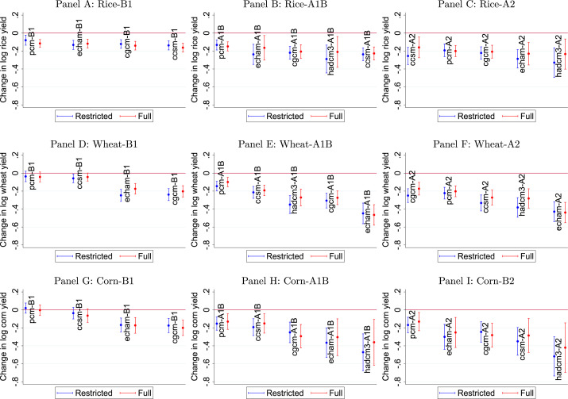

Fig. 4. Climate Prediction using Various Models and Scenarios. *Notes*: This figure presents the climate prediction on the yields of each crop using various climate models. These models include PCM, ECHAM, CGCM, CCSM, and HadCM3, which were used in the IPCC 5th Assessment Report. The forcing scenarios include B1, A1B, and A2. The B1 scenario for HadCM3 is missing. The “Restricted” indicates models with temperature and precipitation only, while the “Full” indicates models with a full set of climatic variables. (For interpretation of the references to color in this figure caption, the reader is referred to the web version of this paper.)

Overall, climate change will have significant impacts on all three crops, ranging from 0 to −50%. Scenario B1 predicts the smallest impacts, while scenario A2 predicts the largest impacts. Furthermore, whether or not to include additional climatic variables makes a difference in the predicted climate impacts.

## Conclusion

This paper explores the importance of additional climatic variables other than temperature and precipitation in estimating the economic impacts of climate change on Chinese agriculture. We find that those additional climatic variables, especially humidity and wind speed, play important roles in crop growth. In general, humidity has beneficial effects on crop growth, while wind speed has detrimental effects. In addition, including those additional climatic variables largely improves the model fit.

Since climate change is likely to lead to a more humid and windier planet, omitting humidity tends to overpredict the cost of climate change, while ignoring wind speeds is likely to cause underprediction. However, as annual average humidity tends to increase under climate change, humidity in the warmest months is likely to decrease because of the increase in extremely high temperatures. Therefore, omitting changes in humidity during the warmest months may underpredict the cost of climate change.

One caveat of our analysis is that our identification relies on year-to-year weather variations. Therefore, we are likely to ignore farmers’ long-run adaptation behaviors such as crop switching and thus overpredict the cost of climate change. Another caveat is that climate change affects not only crop yields but also planted areas (Auffhammer et al., 2006). This topic will be left for future research.

## Acknowledgements

We thank Christopher Costello, David Dawson, Olivier Deschênes, Charles D. Kolstad, Can Wang, Bin Zhang, and Xinye Zheng for helpful comments. We thank seminar participants at UCSB, Tsinghua University, Renmin University of China, and Nanjing University. This project is supported by the National Basic Research Program of China (973 Program) (No. 2012CB955904). Any remaining errors are our own.

## References

1. Ahmed and ul Hassan, 2011

   Mukhtar Ahmed, Fayyaz ul Hassan

   Cumulative effect of temperature and solar radiation on wheat yield

   Notulae Botanicae Horti Agrobotanici Cluj-Napoca, 39 (2011), pp. 146-152

   [View in Scopus](https://www.scopus.com/inward/record.url?eid=2-s2.0-83655192343&partnerID=10&rel=R3.0.0)[Google Scholar](https://scholar.google.com/scholar_lookup?title=Cumulative%20effect%20of%20temperature%20and%20solar%20radiation%20on%20wheat%20yield&publication_year=2011&author=Mukhtar%20Ahmed&author=Fayyaz%20ul%20Hassan)
2. Albouy et al., 2016

   Albouy, David, Graf, Walter, Kellogg, Ryan, 2016. Wolff, Hendrik. Climate amenities, climate change, and American quality of life. J. Assoc. Environ. Resource Econ. 3 (1), 205–246.

   Google Scholar
3. Angrist and Pischke, 2008

   Joshua D Angrist, Jörn-Steffen Pischke

   Mostly Harmless Econometrics: An empiricist's Companion

   Princeton University Press, Princeton (2008)

   [Google Scholar](https://scholar.google.com/scholar_lookup?title=Mostly%20Harmless%20Econometrics%3A%20An%20empiricists%20Companion&publication_year=2008&author=Joshua%20D%20Angrist&author=J%C3%B6rn-Steffen%20Pischke)
4. Arellano, 1987

   Manuel Arellano

   Practitioners' corner: computing robust standard errors for within-groups estimators

   Oxford Bull. Econ. Stat., 49 (4) (1987), pp. 431-434

   [CrossRef](https://doi.org/10.1111/j.1468-0084.1987.mp49004006.x)[View in Scopus](https://www.scopus.com/inward/record.url?eid=2-s2.0-84981567383&partnerID=10&rel=R3.0.0)[Google Scholar](https://scholar.google.com/scholar_lookup?title=Practitioners%20corner%3A%20computing%20robust%20standard%20errors%20for%20within-groups%20estimators&publication_year=1987&author=Manuel%20Arellano)
5. Auffhammer et al., 2013

   Maximilian Auffhammer, Solomon M Hsiang, Wolfram Schlenker, Adam Sobel

   Using weather data and climate model output in economic analyses of climate change

   Rev. Environ. Econ. Policy (2013), p. ret016

   Google Scholar
6. Auffhammer et al., 2006

   Maximilian Auffhammer, Solomon M Hsiang, Wolfram Schlenker, Adam Sobel, V. Ramanathan, Jeffrey R. Vincent

   Integrated model shows that atmospheric brown clouds and greenhouse gases have reduced rice harvests in India

   Proc. Natl. Acad. Sci. USA, 103 (52) (2006), pp. 19668-19672

   [CrossRef](https://doi.org/10.1073/pnas.0609584104)[View in Scopus](https://www.scopus.com/inward/record.url?eid=2-s2.0-33845918063&partnerID=10&rel=R3.0.0)Google Scholar
7. Barreca, 2012

   I. Alan Barreca

   Climate change, humidity, and mortality in the United States

   J. Environ. Econ. Manag., 63 (2012), pp. 19-34

   [View in Scopus](https://www.scopus.com/inward/record.url?eid=2-s2.0-84863747439&partnerID=10&rel=R3.0.0)[Google Scholar](https://scholar.google.com/scholar_lookup?title=Climate%20change%2C%20humidity%2C%20and%20mortality%20in%20the%20United%20States&publication_year=2012&author=I.%20Alan%20Barreca)
8. Batchelor and Roberts, 1983

   C.H. Batchelor, John Roberts

   Evaporation from the irrigation water, foliage and panicles of paddy rice in North-east Sri Lanka

   Agric. Meteorol., 29 (1) (1983), pp. 11-26

   [View PDF](https://www.sciencedirect.com/science/article/pii/0002157183900729/pdf?md5=925e6a7d14cbcefbd57968dd7717f78c&pid=1-s2.0-0002157183900729-main.pdf)[View article](https://www.sciencedirect.com/science/article/pii/0002157183900729)[View in Scopus](https://www.scopus.com/inward/record.url?eid=2-s2.0-0002115063&partnerID=10&rel=R3.0.0)Google Scholar
9. Burke and Emerick, 2016

   Burke, Marshall, Emerick, Kyle, 2016. Adaptation to Climate Change: Evidence from US Agriculture, Am. Econ. J. Econ. Policy. 8 (3), 106-40.

   Google Scholar
10. Burke et al., 2015

    Marshall Burke, Kyle Emerick, John Dykema, David B Lobell, Edward Miguel, Shanker Satyanath

    Incorporating climate uncertainty into estimates of climate change impacts

    Rev. Econ. Stat., 97 (2) (2015), pp. 461-471

    [View in Scopus](https://www.scopus.com/inward/record.url?eid=2-s2.0-84928525829&partnerID=10&rel=R3.0.0)Google Scholar
11. Chen et al., 2015

    Shuai Chen, Xiaoguang Chen, Jintao Xu

    Impacts of climate change on agriculture: evidence from China

    J. Environ. Econ. Manag. (2015)

    Google Scholar
12. Chen et al., 2014

    Chen, Shuai, Chen, Xiaoguang, Xu, Jintao, et al., 2014. The Economic Impact of Weather Variability on China's Rice Sector. Technical Report.

    Google Scholar
13. Conley, 1999

    Timothy G. Conley

    GMM estimation with cross sectional dependence

    J. Econometrics, 92 (1) (1999), pp. 1-45

    [View PDF](https://www.sciencedirect.com/science/article/pii/S0304407698000840/pdfft?md5=81c4faf85ce3892158afe6b74e99d976&pid=1-s2.0-S0304407698000840-main.pdf)[View article](https://www.sciencedirect.com/science/article/pii/S0304407698000840)[View in Scopus](https://www.scopus.com/inward/record.url?eid=2-s2.0-0001912322&partnerID=10&rel=R3.0.0)[Google Scholar](https://scholar.google.com/scholar_lookup?title=GMM%20estimation%20with%20cross%20sectional%20dependence&publication_year=1999&author=Timothy%20G.%20Conley)
14. Dell et al., 2014

    Melissa Dell, Benjamin F. Jones, Benjamin A. Olken

    What do we learn from the weather? the new climate-economy literature

    J. Econ. Lit., 52 (3) (2014), pp. 740-798

    [CrossRef](https://doi.org/10.1257/jel.52.3.740)[View in Scopus](https://www.scopus.com/inward/record.url?eid=2-s2.0-84907443137&partnerID=10&rel=R3.0.0)Google Scholar
15. Deschênes and Greenstone, 2007

    Olivier Deschênes, Michael Greenstone

    The economic impacts of climate change: evidence from agricultural output and random fluctuations in weather

    Am. Econ. Rev. (2007), pp. 354-385

    [View in Scopus](https://www.scopus.com/inward/record.url?eid=2-s2.0-35448996553&partnerID=10&rel=R3.0.0)Google Scholar
16. Deschênes and Greenstone, 2011

    Olivier Deschênes, Michael Greenstone

    Climate change, mortality, and adaptation: evidence from annual fluctuations in weather in the US

    Am. Econ. J. Appl. Econ., 3 (2011), pp. 152-185

    [CrossRef](https://doi.org/10.1257/app.3.4.152)[View in Scopus](https://www.scopus.com/inward/record.url?eid=2-s2.0-80053983353&partnerID=10&rel=R3.0.0)Google Scholar
17. Deschênes and Greenstone, 2012

    Olivier Deschênes, Michael Greenstone

    The economic impacts of climate change: evidence from agricultural output and random fluctuations in weather: reply

    Am. Econ. Rev., 102 (7) (2012), pp. 3761-3773

    [CrossRef](https://doi.org/10.1257/aer.102.7.3761)[View in Scopus](https://www.scopus.com/inward/record.url?eid=2-s2.0-84873316869&partnerID=10&rel=R3.0.0)Google Scholar
18. Feng et al., 2013

    Feng, Shuaizhang, Oppenheimer, Michael, Schlenker, Wolfram, 2013. Weather Anomalies, Crop Yields, and Migration in the US Corn Belt

    Google Scholar
19. Fisher et al., 2012

    Anthony C. Fisher, W. Michael Hanemann, Michael J. Roberts, Wolfram Schlenker

    The economic impacts of climate change: evidence from agricultural output and random fluctuations in weather: comment

    Am. Econ. Rev., 102 (7) (2012), pp. 3749-3760

    [CrossRef](https://doi.org/10.1257/aer.102.7.3749)[View in Scopus](https://www.scopus.com/inward/record.url?eid=2-s2.0-84861824095&partnerID=10&rel=R3.0.0)Google Scholar
20. Gallagher and Biscoe, 1978

    J.N. Gallagher, P.V. Biscoe

    Radiation absorption, growth and yield of cereals

    J. Agric. Sci., 91 (01) (1978), pp. 47-60

    [View in Scopus](https://www.scopus.com/inward/record.url?eid=2-s2.0-84972058215&partnerID=10&rel=R3.0.0)[Google Scholar](https://scholar.google.com/scholar_lookup?title=Radiation%20absorption%2C%20growth%20and%20yield%20of%20cereals&publication_year=1978&author=J.N.%20Gallagher&author=P.V.%20Biscoe)
21. Grace, 1988

    John Grace

    Plant response to wind

    Ecosyst. Environ., 22 (1988), pp. 71-88

    [View PDF](https://www.sciencedirect.com/science/article/pii/0167880988900084/pdf?md5=ac49dc63be149db2bb56c539d6f6a985&pid=1-s2.0-0167880988900084-main.pdf)[View article](https://www.sciencedirect.com/science/article/pii/0167880988900084)[View in Scopus](https://www.scopus.com/inward/record.url?eid=2-s2.0-0024252057&partnerID=10&rel=R3.0.0)[Google Scholar](https://scholar.google.com/scholar_lookup?title=Plant%20response%20to%20wind&publication_year=1988&author=John%20Grace)
22. Gusta and Chen, 1987

    L.V. Gusta, T.H.H. Chen

    The physiology of water and temperature stress

    Wheat and Wheat Improvement (1987), pp. 115-150

    (wheatandwheatim)

    [View in Scopus](https://www.scopus.com/inward/record.url?eid=2-s2.0-85119248787&partnerID=10&rel=R3.0.0)[Google Scholar](https://scholar.google.com/scholar_lookup?title=The%20physiology%20of%20water%20and%20temperature%20stress&publication_year=1987&author=L.V.%20Gusta&author=T.H.H.%20Chen)
23. Hartmann et al., 2013

    Hartmann, D.L., Klein Tank, A.M.G., Rusticucci, M., Alexander, L.V., Brnnimann, S., Charabi, Y., Dentener, F.J., Dlugokencky, E.J., Easterling, D.R., Soden A. Kaplan, B.J., Thorne, P.W., Wild, M., Zhai, P.M., 2013. Observations: atmosphere and surface, In: Stocker, T.F., Qin, D., Plattner, G.-K., Tignor, M., Allen, S.K., Boschung, J., Nauels, A., Xia, Y., Bex, V., Midgley, P.M., (Eds.), 2013. Climate Change 2013: The Physical Science Basis. Contribution of Working Group I to the Fifth Assessment Report of the Intergovernmental Panel on Climate Change. Cambridge University Press.

    Google Scholar
24. Hoffman and Jobes, 1978

    G.J. Hoffman, J.A. Jobes

    Growth and water relations of cereal crops as influenced by salinity and relative humidity

    Agronomy J., 70 (5) (1978), pp. 765-769

    [CrossRef](https://doi.org/10.2134/agronj1978.00021962007000050017x)Google Scholar
25. Hopkins and Hüner, 1995

    William G. Hopkins, Norman P.A. Hüner

    Introduction to Plant Physiology

    vol. 355, Wiley, New York (1995)

    [Google Scholar](https://scholar.google.com/scholar_lookup?title=Introduction%20to%20Plant%20Physiology&publication_year=1995&author=William%20G.%20Hopkins&author=Norman%20P.A.%20H%C3%BCner)
26. Lawrence, 2005

    Mark G. Lawrence

    The relationship between relative humidity and the dewpoint temperature in moist air: a simple conversion and applications

    Bull. Am. Meteorol. Soc., 86 (2) (2005), pp. 225-233

    [CrossRef](https://doi.org/10.1175/BAMS-86-2-225)[View in Scopus](https://www.scopus.com/inward/record.url?eid=2-s2.0-15044339284&partnerID=10&rel=R3.0.0)Google Scholar
27. Liu, 1993

    Xunhao Liu

    Chinese Cropping System

    China Agriculture Press, Beijing (1993)

    [Google Scholar](https://scholar.google.com/scholar_lookup?title=Chinese%20Cropping%20System&publication_year=1993&author=Xunhao%20Liu)
28. Lobell et al., 2013

    David B Lobell, G.L. Hammer, Greg McLean, Carlos Messina, Michael J Roberts, Wolfram Schlenker

    The critical role of extreme heat for maize production in the United States

    Nat. Clim. Change, 3 (5) (2013), pp. 497-501

    [CrossRef](https://doi.org/10.1038/nclimate1832)[View in Scopus](https://www.scopus.com/inward/record.url?eid=2-s2.0-84877049806&partnerID=10&rel=R3.0.0)Google Scholar
29. Mendelsohn et al., 1994

    Robert Mendelsohn, William D Nordhaus, Daigee Shaw

    The impact of global warming on agriculture: a Ricardian analysis

    Am. Econ. Rev. (1994), pp. 753-771

    [View in Scopus](https://www.scopus.com/inward/record.url?eid=2-s2.0-0028600234&partnerID=10&rel=R3.0.0)Google Scholar
30. Miao et al., 2016

    Ruiqing Miao, Madhu Khanna, Haixiao Huang

    Responsiveness of crop yield and acreage to prices and climate

    Am. J. Agric. Econ., 98 (1) (2016), pp. 191-211

    [CrossRef](https://doi.org/10.1093/ajae/aav025)[View in Scopus](https://www.scopus.com/inward/record.url?eid=2-s2.0-84954308248&partnerID=10&rel=R3.0.0)Google Scholar
31. Monteith and Unsworth, 2013

    John Monteith, Mike Unsworth

    Principles of Environmental Physics: Plants, Animals, and the Atmosphere

    Academic Press, Cambridge (2013)

    Google Scholar
32. Nkemdirim, 1991

    L.C. Nkemdirim

    An empirical relationship between temperature, vapour pressure deficit and wind speed and evaporation during a winter chinook

    Theoret. Appl. Climatol., 43 (3) (1991), pp. 123-128

    [View in Scopus](https://www.scopus.com/inward/record.url?eid=2-s2.0-0009761439&partnerID=10&rel=R3.0.0)Google Scholar
33. Nobel, 1981

    P.S. Nobel

    Wind as an ecological factor

    Springer, Berlin Heidelberg (1981)

    [Google Scholar](https://scholar.google.com/scholar_lookup?title=Wind%20as%20an%20ecological%20factor&publication_year=1981&author=P.S.%20Nobel)
34. Rawson et al., 1977

    H.M. Rawson, J.E. Begg, R.G. Woodward

    The effect of atmospheric humidity on photosynthesis, transpiration and water use efficiency of leaves of several plant species

    Planta, 134 (1) (1977), pp. 5-10

    [View in Scopus](https://www.scopus.com/inward/record.url?eid=2-s2.0-0002914522&partnerID=10&rel=R3.0.0)Google Scholar
35. Rebetez and Beniston, 1998

    Martine Rebetez, Martin Beniston

    Changes in sunshine duration are correlated with changes in daily temperature range this century: an analysis of swiss climatological data

    Geophys. Res. Lett., 25 (19) (1998), pp. 3611-3613

    [View in Scopus](https://www.scopus.com/inward/record.url?eid=2-s2.0-0032193993&partnerID=10&rel=R3.0.0)Google Scholar
36. Richards, 2006

    Richard A. Richards

    Physiological traits used in the breeding of new cultivars for water-scarce environments

    Agric. Water Manag., 80 (1) (2006), pp. 197-211

    [View PDF](https://www.sciencedirect.com/science/article/pii/S0378377405002982/pdfft?md5=df5b288ce9bcdd01a9cf7e8c98b8ea43&pid=1-s2.0-S0378377405002982-main.pdf)[View article](https://www.sciencedirect.com/science/article/pii/S0378377405002982)[View in Scopus](https://www.scopus.com/inward/record.url?eid=2-s2.0-31544465463&partnerID=10&rel=R3.0.0)Google Scholar
37. Roberts et al., 2012

    Michael J. Roberts, Wolfram Schlenker, Jonathan Eyer

    Agronomic weather measures in econometric models of crop yield with implications for climate change

    Am. J. Agric. Econ. (2012), p. aas047

    Google Scholar
38. Roderick and Farquhar, 2002

    Michael L. Roderick, Graham D. Farquhar

    The cause of decreased pan evaporation over the past 50 years

    Science, 298 (5597) (2002), pp. 1410-1411

    [CrossRef](https://doi.org/10.1126/science.1075390-a)[View in Scopus](https://www.scopus.com/inward/record.url?eid=2-s2.0-0037111871&partnerID=10&rel=R3.0.0)Google Scholar
39. Sadras and Milroy, 1996

    V.O. Sadras, S.P. Milroy

    Soil-water thresholds for the responses of leaf expansion and gas exchange: a review

    Field Crops Res., 47 (2) (1996), pp. 253-266

    [View PDF](https://www.sciencedirect.com/science/article/pii/0378429096000147/pdf?md5=b4dd364b7956524adc3fc6337958f676&pid=1-s2.0-0378429096000147-main.pdf)[View article](https://www.sciencedirect.com/science/article/pii/0378429096000147)[View in Scopus](https://www.scopus.com/inward/record.url?eid=2-s2.0-0030220459&partnerID=10&rel=R3.0.0)Google Scholar
40. Schlenker and Roberts, 2009

    Wolfram Schlenker, Michael J. Roberts

    Nonlinear temperature effects indicate severe damages to US crop yields under climate change

    Proc. Natl. Acad. Sci. USA, 106 (37) (2009), pp. 15594-15598

    [CrossRef](https://doi.org/10.1073/pnas.0906865106)[View in Scopus](https://www.scopus.com/inward/record.url?eid=2-s2.0-70349456137&partnerID=10&rel=R3.0.0)Google Scholar
41. Schlenker et al., 2005

    Wolfram Schlenker, Michael J. Roberts, W. Michael Hanemann, Anthony C. Fisher

    Will US agriculture really benefit from global warming? accounting for irrigation in the hedonic approach

    Am. Econ. Rev. (2005), pp. 395-406

    [CrossRef](https://doi.org/10.1257/0002828053828455)[View in Scopus](https://www.scopus.com/inward/record.url?eid=2-s2.0-20444371051&partnerID=10&rel=R3.0.0)Google Scholar
42. Schlenker et al., 2006

    Wolfram Schlenker, Michael J. Roberts, W. Michael Hanemann, Anthony C. Fisher

    The impact of global warming on us agriculture: an econometric analysis of optimal growing conditions

    Rev. Econ. Stat., 88 (1) (2006), pp. 113-125

    [View in Scopus](https://www.scopus.com/inward/record.url?eid=2-s2.0-32544453816&partnerID=10&rel=R3.0.0)Google Scholar
43. Solon et al., 2013

    Solon, Gary, Haider, Steven J., Wooldridge, Jeffrey, 2013. What Are We Weighting For?. No. w18859. National Bureau of Economic Research.

    Google Scholar
44. Wallace, 2000

    J.S. Wallace

    Increasing agricultural water use efficiency to meet future food production

    Agric. Ecosyst. Environ., 82 (1) (2000), pp. 105-119

    [View PDF](https://www.sciencedirect.com/science/article/pii/S0167880900002206/pdfft?md5=1de7919c11f2b74b590e42562dfff42a&pid=1-s2.0-S0167880900002206-main.pdf)[View article](https://www.sciencedirect.com/science/article/pii/S0167880900002206)[View in Scopus](https://www.scopus.com/inward/record.url?eid=2-s2.0-0033672848&partnerID=10&rel=R3.0.0)[Google Scholar](https://scholar.google.com/scholar_lookup?title=Increasing%20agricultural%20water%20use%20efficiency%20to%20meet%20future%20food%20production&publication_year=2000&author=J.S.%20Wallace)
45. Welch et al., 2010

    Jarrod R. Welch, Jeffrey R. Vincent, Maximilian Auffhammer, Piedad F. Moya, Achim Dobermann, David Dawe

    Rice yields in tropical/subtropical asia exhibit large but opposing sensitivities to minimum and maximum temperatures

    Proc. Natl. Acad. Sci. USA (2010)

    Google Scholar
46. Wooldridge, 2003

    Jeffrey M. Wooldridge

    Cluster-sample methods in applied econometrics

    Am. Econ. Rev., 93 (2) (2003), pp. 133-138

    [View in Scopus](https://www.scopus.com/inward/record.url?eid=2-s2.0-1242345357&partnerID=10&rel=R3.0.0)[Google Scholar](https://scholar.google.com/scholar_lookup?title=Cluster-sample%20methods%20in%20applied%20econometrics&publication_year=2003&author=Jeffrey%20M.%20Wooldridge)
47. Wooten, 2011

    R.D. Wooten

    Statistical analysis of the relationship between wind speed, pressure and temperature

    J. Appl. Sci., 11 (2011), p. 15

    [Google Scholar](https://scholar.google.com/scholar_lookup?title=Statistical%20analysis%20of%20the%20relationship%20between%20wind%20speed%2C%20pressure%20and%20temperature&publication_year=2011&author=R.D.%20Wooten)
48. Zhao, 2010a

    Guangcai Zhao

    Study on chinese wheat planting regionalization (I)

    J. Triticeae Crops, 30 (5) (2010), pp. 886-895

    [View in Scopus](https://www.scopus.com/inward/record.url?eid=2-s2.0-78649997374&partnerID=10&rel=R3.0.0)[Google Scholar](https://scholar.google.com/scholar_lookup?title=Study%20on%20chinese%20wheat%20planting%20regionalization%20&publication_year=2010&author=Guangcai%20Zhao)
49. Zhao, 2010b

    Guangcai Zhao

    Study on chinese wheat planting regionalization (II)

    J. Triticeae Crops, 30 (6) (2010), pp. 1140-1147

    [View in Scopus](https://www.scopus.com/inward/record.url?eid=2-s2.0-77954800810&partnerID=10&rel=R3.0.0)[Google Scholar](https://scholar.google.com/scholar_lookup?title=Study%20on%20chinese%20wheat%20planting%20regionalization%20&publication_year=2010&author=Guangcai%20Zhao)

- 2024, Journal of Cleaner Production

- 2024, Environmental Pollution

- 2024, Journal of Development Economics

- 2024, Journal of Development Economics

- 2024, Structural Change and Economic Dynamics

- 2024, Energy Economics

**<sup>1</sup>**

Relative humidity is a common measurement for humidity. It is defined as the ratio of the amount of water vapor in air to the maximum water vapor that air can hold at the given temperature. Humidity can also be approximately measured by vapor pressure deficit (VPD). We also explore the effect of VPD. In the rest of the paper, we use “humidity” interchangeably with “relative humidity.”

**<sup>2</sup>**

For example, Welch et al. (2010) and Chen et al. (2015) include solar radiation in addition to temperature and precipitation. Roberts et al. (2012) and Lobell et al. (2013) include vapor pressure deficit, which is used to approximately measure humidity, in addition to temperature and precipitation.

**<sup>3</sup>**

We thank a referee for pointing out this.

**<sup>4</sup>**

Chen et al. (2015) provide the first study of estimating the effect of climate change on Chinese agriculture.

**<sup>5</sup>**

China Statistical Yearbook, 2012. http://www.stats.gov.cn/tjsj/ndsj/2012/indexeh.htm

**<sup>6</sup>**

World Bank, 2012. http://data.worldbank.org/indicator

**<sup>7</sup>**

US Department of Agriculture, 2012. http://apps.fas.usda.gov/psdonline/psdHome.aspx

**<sup>8</sup>**

We do not compare the distributions of sunshine duration and evaporation because Hadley Centre does not predict for these two variables.

**<sup>9</sup>**

China Statistical Yearbook, 2012. http://www.stats.gov.cn/tjsj/ndsj/2012/indexeh.htm

**<sup>10</sup>**

U.S. Bureau of Economic Analysis, 2012. http://www.bea.gov/industry/gdpbyind_data.htm

**<sup>11</sup>**

World Bank, 2012. http://data.worldbank.org/indicator

**<sup>12</sup>**

US Department of Agriculture, 2012. http://apps.fas.usda.gov/psdonline/psdHome.aspx. In comparison, the United States produces 1% of the rice, 9% of the wheat, and 31% of the corn in the world.

**<sup>13</sup>**

China Statistical Yearbook, 2012. http://www.stats.gov.cn/tjsj/ndsj/2012/indexeh.htm

**<sup>14</sup>**

China Statistical Yearbook, 2012. http://www.stats.gov.cn/tjsj/ndsj/2012/indexeh.htm

**<sup>15</sup>**

〈http://www.sdpc.gov.cn/zcfb/zcfbtz/201411/W020141104584717807138.pdf

**<sup>16</sup>**

http://nc.ccchina.gov.cn/english/

**<sup>17</sup>**

We are only aware that Chen et al., 2014, Chen et al., 2015 evaluate the impact of climate change on Chinese agriculture.

**<sup>18</sup>**

In the analysis we assume the growing season is fixed over time because we are lack of data on growing season across years. Therefore we may overestimate the climate cost because farmers may adapt to climate change by varying planted and harvested dates.

**<sup>19</sup>**

Our agriculture data start from 1980. Since the growing season for wheat in certain regions is from previous year, we also need weather data in 1979.

**<sup>20</sup>**

We also conduct a robustness check to test the impact of dropping high-elevation stations. The results are almost the same, because most stations with elevation greater than 3000 meters are located in the Qinghai-Tibet Plateau, where has very few agricultural activities.

**<sup>21</sup>**

Auffhammer et al. (2013) suggest that it is important to have a relatively continuous weather record for weather stations when averaging daily station-level data across space. This is because when location and time fixed effects are included in the regression, the weather variation is greatly decreased relative to the cross-sectional setting, and thus the missing values of station-level data can potentially account for a large share of the overall variances. This is a minor issue for our weather data thanks to the quality assurance by the National Meteorological Information Center of China. The share of the missing values in the total observations is less than 0.01% for temperature, precipitation, relative humidity, wind speed, and sunshine duration. However, the share for evaporation is about 25%. Thus, we drop stations with large missing values for evaporation.

**<sup>22</sup>**

The data can be downloaded at http://badc.nerc.ac.uk/view/badc.nerc.ac.uk__ATOM__dataent_12024019658225569

**<sup>23</sup>**

Since the grid points of the Hadley CM3 are relatively disperse, we change the radius to 300 km, to ensure that each county have valid observations for every day over the period 2070–2099.

**<sup>24</sup>**

In agronomy, crop planted area slightly differs from harvested area. In our data, we only observe planted area.

**<sup>25</sup>**

We do not use smaller temperature intervals such as 1 °C or 3 °C because our sample size is smaller than that of Schlenker and Roberts (2009).

**<sup>26</sup>**

There are generally two approaches to study the economic impacts of climate change on agriculture in the economics literature. The first one is the hedonic approach (Mendelsohn et al., 1994, Schlenker et al., 2005, Schlenker et al., 2006), which regresses the long-run average land values on long-run climate averages in a cross-sectional setting. The second approach is the panel-data approach (Deschênes and Greenstone, 2007, Schlenker and Roberts, 2009), which regresses the land profits or crop yields on year-to-year weather fluctuations. We do not use the hedonic approach because farmland is not tradable in China. Therefore, the fundamental assumption–well-functioning land markets–of the hedonic approach is violated. See Dell et al. (2014) for a detailed discussion about the two approaches.

**<sup>27</sup>**

In the robustness check, we replace year fixed effects with province-specific quadratic time trends, and the results are robust.

**<sup>28</sup>**

As a robustness check, we also report the estimates without weighting and the results are robust.

**<sup>29</sup>**

In China, province is the principal administrative division. Prefecture is between province and county. We do not cluster by province since our data only have 29 provinces, which are relatively small to cluster (Angrist and Pischke, 2008).

**<sup>30</sup>**

We do no use the root mean squared (RMS) error for out-of-sample forecast because the time period in our sample is quite short, with only 11 years.

**<sup>31</sup>**

We do not further differentiate temperatures between 30–35 °C and above 35 °C since the effects of above 35 °C is not well estimated because of the less frequency and small variation.

**<sup>32</sup>**

http://www.stats.gov.cn/english/Statisticaldata/AnnualData/

**<sup>33</sup>**

Miao et al. (2016) show that price variables are also important to account for when estimating the effect of climate change on the U.S. agriculture. However, we are not able to obtain price variables in early 1980s. As Chen et al. (2015) show that the estimated coefficients of temperature and precipitation are generally robust when adding price variables, omitting price variables should have limited effect on our analysis.

**<sup>34</sup>**

When we interact the highest temperature range with month-specific humidity for rice and with the seasonal average humidity for wheat, the interactions remain statistically insignificant as well.

**<sup>35</sup>**

© 2016 Elsevier Inc. All rights reserved.

- Journal of Environmental Economics and Management, Volume 94, 2019, pp. 236-253

  Zihan Hu, Teng Li

  [View PDF](https://www.sciencedirect.com/science/article/pii/S0095069618301025/pdfft?md5=a163bebe0cd40c2ba2692b9984154131&pid=1-s2.0-S0095069618301025-main.pdf)

- Journal of Environmental Economics and Management, Volume 96, 2019, pp. 195-212

  Xiumei Yu, …, Min Wang

  [View PDF](https://www.sciencedirect.com/science/article/pii/S0095069618304054/pdfft?md5=9b7c878cb15763faafdd9613a6795dee&pid=1-s2.0-S0095069618304054-main.pdf)

- China Economic Review, Volume 62, 2020, Article 101256

  Wei Xie, …, Kevin Chen

  [View PDF](https://www.sciencedirect.com/science/article/pii/S1043951X18301688/pdfft?md5=617cc9da85bcb73e2925862a33524e79&pid=1-s2.0-S1043951X18301688-main.pdf)

Citations

Captures

- Readers: 441

Mentions

- Blog Mentions: 1